# Project: Investigate Gun Data

- Introduction
- Data Wrangling
- Exploratory Data Analysis
- Conclusions

## Introduction

The data comes from the FBI's National Instant Criminal Background Check System. The NICS is used by to determine whether a prospective buyer is eligible to buy firearms or explosives. Gun shops call into this system to ensure that each customer does not have a criminal record or isn’t otherwise ineligible to make a purchase. The data has been supplemented with state level data from census.gov.

Gun Data:

1. Has the overall purchase of guns increased over the years?
2. Which state has the highest growth in gun registrations?
3. Which Gun type is preferred?
4. Which Top 5 States have the most the gun purchase related activity?

Census Data:

1. What census data is most associated with high gun per capita?
2. What can be found about the top 5 census data on the states with maximum gun registrations?

```python
import pandas as pd
import re
import numpy as np
import matplotlib.pyplot as plt
import seaborn as sns
% matplotlib inline
```

## Data Wrangling

### General Properties

```python
#Loading gun data
df_gun=pd.read_excel('gun_data.xlsx', sheet_name=None)
```

#### Note 1:

> The settings indicates below are required to ensure that the entire list of columns and data can be viewed within the notebook

```python
pd.options.display.max_rows = 100
pd.options.display.max_columns=50
pd.set_option('max_colwidth',100)
pd.set_option('expand_frame_repr',True)
pd.set_option('precision',4)
```

```python
#verify the first 5 rows of data in the gun data set.
df_gun.head(5)
```

|  | month | state | permit | permit_recheck | handgun | long_gun | other | multiple | admin | prepawn_handgun | prepawn_long_gun | prepawn_other | redemption_handgun | redemption_long_gun | redemption_other | returned_handgun | returned_long_gun | returned_other | rentals_handgun | rentals_long_gun | private_sale_handgun | private_sale_long_gun | private_sale_other | return_to_seller_handgun | return_to_seller_long_gun | return_to_seller_other | totals |
| --- | --- | --- | --- | --- | --- | --- | --- | --- | --- | --- | --- | --- | --- | --- | --- | --- | --- | --- | --- | --- | --- | --- | --- | --- | --- | --- | --- |
| 0 | 2017-09 | Alabama | 16,717.00 | 0.00 | 5,734.00 | 6,320.00 | 221.00 | 317 | 0.00 | 15.00 | 21.00 | 2.00 | 1,378.00 | 1,262.00 | 1.00 | 0.00 | 0.00 | 0.00 | 0.00 | 0.00 | 9.00 | 16.00 | 3.00 | 0.00 | 0.00 | 3.00 | 32019 |
| 1 | 2017-09 | Alaska | 209.00 | 2.00 | 2,320.00 | 2,930.00 | 219.00 | 160 | 0.00 | 5.00 | 2.00 | 0.00 | 200.00 | 154.00 | 2.00 | 28.00 | 30.00 | 0.00 | 0.00 | 0.00 | 17.00 | 24.00 | 1.00 | 0.00 | 0.00 | 0.00 | 6303 |
| 2 | 2017-09 | Arizona | 5,069.00 | 382.00 | 11,063.00 | 7,946.00 | 920.00 | 631 | 0.00 | 13.00 | 6.00 | 0.00 | 1,474.00 | 748.00 | 3.00 | 82.00 | 5.00 | 0.00 | 0.00 | 0.00 | 38.00 | 12.00 | 2.00 | 0.00 | 0.00 | 0.00 | 28394 |
| 3 | 2017-09 | Arkansas | 2,935.00 | 632.00 | 4,347.00 | 6,063.00 | 165.00 | 366 | 51.00 | 12.00 | 13.00 | 0.00 | 1,296.00 | 1,824.00 | 4.00 | 0.00 | 0.00 | 0.00 | 0.00 | 0.00 | 13.00 | 23.00 | 0.00 | 0.00 | 2.00 | 1.00 | 17747 |
| 4 | 2017-09 | California | 57,839.00 | 0.00 | 37,165.00 | 24,581.00 | 2,984.00 | 0 | 0.00 | 0.00 | 0.00 | 0.00 | 535.00 | 397.00 | 5.00 | 0.00 | 0.00 | 0.00 | 0.00 | 0.00 | 0.00 | 0.00 | 0.00 | 0.00 | 0.00 | 0.00 | 123506 |

```python
df_gun.shape
```

```
(12485, 27)
```

This dataset contains 12485 rows and 27 columns of information regarding gun checks

```python
df_gun.describe()
```

|  | permit | permit_recheck | handgun | long_gun | other | multiple | admin | prepawn_handgun | prepawn_long_gun | prepawn_other | redemption_handgun | redemption_long_gun | redemption_other | returned_handgun | returned_long_gun | returned_other | rentals_handgun | rentals_long_gun | private_sale_handgun | private_sale_long_gun | private_sale_other | return_to_seller_handgun | return_to_seller_long_gun | return_to_seller_other | totals |
| --- | --- | --- | --- | --- | --- | --- | --- | --- | --- | --- | --- | --- | --- | --- | --- | --- | --- | --- | --- | --- | --- | --- | --- | --- | --- |
| count | 12,461.00 | 1,100.00 | 12,465.00 | 12,466.00 | 5,500.00 | 12,485.00 | 12,462.00 | 10,542.00 | 10,540.00 | 5,115.00 | 10,545.00 | 10,544.00 | 5,115.00 | 2,200.00 | 2,145.00 | 1,815.00 | 990.00 | 825.00 | 2,750.00 | 2,750.00 | 2,750.00 | 2,475.00 | 2,750.00 | 2,255.00 | 12,485.00 |
| mean | 6,413.63 | 1,165.96 | 5,940.88 | 7,810.85 | 360.47 | 268.60 | 58.90 | 4.83 | 7.83 | 0.17 | 407.97 | 599.33 | 1.82 | 29.61 | 7.56 | 1.03 | 0.08 | 0.09 | 14.94 | 11.60 | 1.03 | 0.40 | 0.44 | 0.11 | 21,595.73 |
| std | 23,752.34 | 9,224.20 | 8,618.58 | 9,309.85 | 1,349.48 | 783.19 | 604.81 | 10.91 | 16.47 | 1.06 | 783.47 | 952.14 | 4.57 | 81.94 | 22.10 | 4.39 | 0.63 | 0.67 | 71.22 | 54.25 | 4.47 | 1.45 | 1.53 | 0.43 | 32,591.42 |
| min | 0.00 | 0.00 | 0.00 | 0.00 | 0.00 | 0.00 | 0.00 | 0.00 | 0.00 | 0.00 | 0.00 | 0.00 | 0.00 | 0.00 | 0.00 | 0.00 | 0.00 | 0.00 | 0.00 | 0.00 | 0.00 | 0.00 | 0.00 | 0.00 | 0.00 |
| 25% | 0.00 | 0.00 | 865.00 | 2,078.25 | 17.00 | 15.00 | 0.00 | 0.00 | 0.00 | 0.00 | 0.00 | 0.00 | 0.00 | 0.00 | 0.00 | 0.00 | 0.00 | 0.00 | 0.00 | 0.00 | 0.00 | 0.00 | 0.00 | 0.00 | 4,638.00 |
| 50% | 518.00 | 0.00 | 3,059.00 | 5,122.00 | 121.00 | 125.00 | 0.00 | 0.00 | 1.00 | 0.00 | 39.00 | 175.00 | 0.00 | 0.00 | 0.00 | 0.00 | 0.00 | 0.00 | 0.00 | 0.00 | 0.00 | 0.00 | 0.00 | 0.00 | 12,399.00 |
| 75% | 4,272.00 | 0.00 | 7,280.00 | 10,380.75 | 354.00 | 301.00 | 0.00 | 5.00 | 8.00 | 0.00 | 561.00 | 872.00 | 2.00 | 16.00 | 4.00 | 0.00 | 0.00 | 0.00 | 2.00 | 4.00 | 0.00 | 0.00 | 0.00 | 0.00 | 25,453.00 |
| max | 522,188.00 | 116,681.00 | 107,224.00 | 108,058.00 | 77,929.00 | 38,907.00 | 28,083.00 | 164.00 | 269.00 | 49.00 | 10,046.00 | 8,831.00 | 79.00 | 603.00 | 168.00 | 64.00 | 12.00 | 12.00 | 1,017.00 | 777.00 | 71.00 | 28.00 | 17.00 | 4.00 | 541,978.00 |

```python
df_gun.count()
```

```
month                        12485
state                        12485
permit                       12461
permit_recheck                1100
handgun                      12465
long_gun                     12466
other                         5500
multiple                     12485
admin                        12462
prepawn_handgun              10542
prepawn_long_gun             10540
prepawn_other                 5115
redemption_handgun           10545
redemption_long_gun          10544
redemption_other              5115
returned_handgun              2200
returned_long_gun             2145
returned_other                1815
rentals_handgun                990
rentals_long_gun               825
private_sale_handgun          2750
private_sale_long_gun         2750
private_sale_other            2750
return_to_seller_handgun      2475
return_to_seller_long_gun     2750
return_to_seller_other        2255
totals                       12485
dtype: int64
```

#### Note 2:

The dataset does not require any additional cleanup. The data can be categorized to analyze better.

Category 1: The Guns can be classified into long gun/hand Gun/Other

Category 2: The permit and permit recheck can be summed up

Category 3: The Totals will be useful to compare all states to find out the maximum gun activity

The month and year can be split up, and we can show the trend from 2010 and drop anything older than that, since census data below has data between the range of 2010 - 2016

```python
# Loading file 2 containing census data
df_census=pd.read_csv('U.S. Census Data.csv')
```

```python
df_census.head(5)
```

|  | Fact | Fact Note | Alabama | Alaska | Arizona | Arkansas | California | Colorado | Connecticut | Delaware | Florida | Georgia | Hawaii | Idaho | Illinois | Indiana | Iowa | Kansas | Kentucky | Louisiana | Maine | Maryland | Massachusetts | Michigan | Minnesota | ... | Montana | Nebraska | Nevada | … |
| --- | --- | --- | --- | --- | --- | --- | --- | --- | --- | --- | --- | --- | --- | --- | --- | --- | --- | --- | --- | --- | --- | --- | --- | --- | --- | --- | --- | --- | --- | --- |
| 0 | Population estimates, July 1, 2016, (V2016) | NaN | 4,863,300 | 741,894 | 6,931,071 | 2,988,248 | 39,250,017 | 5,540,545 | 3,576,452 | 952,065 | 20,612,439 | 10,310,371 | 1,428,557 | 1,683,140 | 12,801,539 | 6,633,053 | 3,134,693 | 2,907,289 | 4,436,974 | 4,681,666 | 1,331,479 | 6,016,447 | 6,811,779 | 9,928,300 | 5,519,952 | ... | 1,042,520 | 1,907,116 | 2,940,058 | … |
| 1 | Population estimates base, April 1, 2010, (V2016) | NaN | 4,780,131 | 710,249 | 6,392,301 | 2,916,025 | 37,254,522 | 5,029,324 | 3,574,114 | 897,936 | 18,804,592 | 9,688,680 | 1,360,301 | 1,567,650 | 12,831,574 | 6,484,136 | 3,046,869 | 2,853,129 | 4,339,344 | 4,533,479 | 1,328,364 | 5,773,786 | 6,547,813 | 9,884,129 | 5,303,924 | ... | 989,414 | 1,826,334 | 2,700,691 | … |
| 2 | Population, percent change - April 1, 2010 (estimates base) to July 1, 2016, (V2016) | NaN | 1.70% | 4.50% | 8.40% | 2.50% | 5.40% | 10.20% | 0.10% | 6.00% | 9.60% | 6.40% | 5.00% | 7.40% | -0.20% | 2.30% | 2.90% | 1.90% | 2.20% | 3.30% | 0.20% | 4.20% | 4.00% | 0.40% | 4.10% | ... | 5.40% | 4.40% | 8.90% | … |
| 3 | Population, Census, April 1, 2010 | NaN | 4,779,736 | 710,231 | 6,392,017 | 2,915,918 | 37,253,956 | 5,029,196 | 3,574,097 | 897,934 | 18,801,310 | 9,687,653 | 1,360,301 | 1,567,582 | 12,830,632 | 6,483,802 | 3,046,355 | 2,853,118 | 4,339,367 | 4,533,372 | 1,328,361 | 5,773,552 | 6,547,629 | 9,883,640 | 5,303,925 | ... | 989,415 | 1,826,341 | 2,700,551 | … |
| 4 | Persons under 5 years, percent, July 1, 2016, (V2016) | NaN | 6.00% | 7.30% | 6.30% | 6.40% | 6.30% | 6.10% | 5.20% | 5.80% | 5.50% | 6.40% | 6.40% | 6.80% | 6.00% | 6.40% | 6.40% | 6.70% | 6.20% | 6.60% | 4.90% | 6.10% | 5.30% | 5.80% | 6.40% | ... | 6.00% | 7.00% | 6.30% | … |

5 rows × 52 columns

```python
df_census.shape
```

```
(85, 52)
```

```python
df_census.describe()
```

|  | Fact | Fact Note | Alabama | Alaska | Arizona | Arkansas | California | Colorado | Connecticut | Delaware | Florida | Georgia | Hawaii | Idaho | Illinois | Indiana | Iowa | Kansas | Kentucky | Louisiana | Maine | Maryland | Massachusetts | Michigan | Minnesota | ... | Montana | Nebraska | Nevada | … |
| --- | --- | --- | --- | --- | --- | --- | --- | --- | --- | --- | --- | --- | --- | --- | --- | --- | --- | --- | --- | --- | --- | --- | --- | --- | --- | --- | --- | --- | --- | --- |
| count | 80 | 28 | 65 | 65 | 65 | 65 | 65 | 65 | 65 | 65 | 65 | 65 | 65 | 65 | 65 | 65 | 65 | 65 | 65 | 65 | 65 | 65 | 65 | 65 | 65 | ... | 65 | 65 | 65 | … |
| unique | 80 | 15 | 65 | 64 | 64 | 64 | 63 | 64 | 63 | 64 | 64 | 64 | 63 | 63 | 65 | 63 | 65 | 65 | 65 | 65 | 64 | 64 | 65 | 64 | 65 | ... | 65 | 65 | 63 | … |
| top | Total employer establishments, 2015 | (c) | 58,564,965 | 7.30% | 50.30% | 50.90% | 50.30% | 3.30% | 0.10% | 51.60% | 51.10% | 6.40% | 6.40% | 82.40% | 5.50% | 9.70% | $697 | $455 | 5.10% | 104.9 | 1.60% | 51.60% | 2.90% | 6.30% | 148,666 | ... | 89.20% | 13.50% | 49.90% | … |
| freq | 1 | 6 | 1 | 2 | 2 | 2 | 2 | 2 | 2 | 2 | 2 | 2 | 2 | 2 | 1 | 2 | 1 | 1 | 1 | 1 | 2 | 2 | 1 | 2 | 1 | ... | 1 | 1 | 2 | … |

4 rows × 52 columns

#### Note 24:

> There various types of values within each state, further investigation would be needed to standardize this data.

```python
df_census.count()
```

```
Fact              80
Fact Note         28
Alabama           65
Alaska            65
Arizona           65
Arkansas          65
California        65
Colorado          65
Connecticut       65
Delaware          65
Florida           65
Georgia           65
Hawaii            65
Idaho             65
Illinois          65
Indiana           65
Iowa              65
Kansas            65
Kentucky          65
Louisiana         65
Maine             65
Maryland          65
Massachusetts     65
Michigan          65
Minnesota         65
Mississippi       65
Missouri          65
Montana           65
Nebraska          65
Nevada            65
New Hampshire     65
New Jersey        65
New Mexico        65
New York          65
North Carolina    65
North Dakota      65
Ohio              65
Oklahoma          65
Oregon            65
Pennsylvania      65
Rhode Island      65
South Carolina    65
South Dakota      65
Tennessee         65
Texas             65
Utah              65
Vermont           65
Virginia          65
Washington        65
West Virginia     65
Wisconsin         65
Wyoming           65
dtype: int64
```

#### Note 5:

There are only 65 rows of actual data in the census data, the rest can be dropped.

The data is not time bound, but some year values can be stripped from the Fact column to make them time bound

The columns are states and will need to be transposed to come up with a comparison

The Fact note can be dropped and the Fact column needs to be the indexed

The data types & column names need to be standardized

### Data Cleaning

#### Gun data Observations

1. Standardize data types
2. Split month and year, so the data can be summarized.
3. Categorize the data as observed above.
4. Fill in all null values
5. Remove duplicates

#### Census data Observations

1. Strip years fact column so that the data can be time bound
2. Indicate the measurement unit of the fact as % , \$ , \$1000 or none
3. Convert each census data into a simple column name
4. Drop unnecessary rows
5. fill nulls with 0 and standardize all data types

```python
df_gun.info()
```

```
<class 'pandas.core.frame.DataFrame'>
RangeIndex: 12485 entries, 0 to 12484
Data columns (total 27 columns):
month                        12485 non-null object
state                        12485 non-null object
permit                       12461 non-null float64
permit_recheck               1100 non-null float64
handgun                      12465 non-null float64
long_gun                     12466 non-null float64
other                        5500 non-null float64
multiple                     12485 non-null int64
admin                        12462 non-null float64
prepawn_handgun              10542 non-null float64
prepawn_long_gun             10540 non-null float64
prepawn_other                5115 non-null float64
redemption_handgun           10545 non-null float64
redemption_long_gun          10544 non-null float64
redemption_other             5115 non-null float64
returned_handgun             2200 non-null float64
returned_long_gun            2145 non-null float64
returned_other               1815 non-null float64
rentals_handgun              990 non-null float64
rentals_long_gun             825 non-null float64
private_sale_handgun         2750 non-null float64
private_sale_long_gun        2750 non-null float64
private_sale_other           2750 non-null float64
return_to_seller_handgun     2475 non-null float64
return_to_seller_long_gun    2750 non-null float64
return_to_seller_other       2255 non-null float64
totals                       12485 non-null int64
dtypes: float64(23), int64(2), object(2)
memory usage: 2.6+ MB
```

#### Note 6:

The string columns for any numerical values must be converted to float.

```python
df_gun['totals'] = df_gun['totals'].astype(float)
df_gun['multiple'] = df_gun['multiple'].astype(float)
```

#### Note 7:

The year needs to be seperated from the monthyear column so that the data can be aggregated and dropped as needed.

```python
df_gun['monthyear'] =  pd.to_datetime(df_gun['month'], format='%Y-%m')
df_gun['Year'] = df_gun['monthyear'].apply(lambda x:x.date().strftime('%Y'))
df_gun['month'] = df_gun['monthyear'].apply(lambda x:x.date().strftime('%m'))
df_gun.drop('monthyear', axis=1,inplace=True)
```

```python
df_gun.head(5)
```

|  | month | state | permit | permit_recheck | handgun | long_gun | other | multiple | admin | prepawn_handgun | prepawn_long_gun | prepawn_other | redemption_handgun | redemption_long_gun | redemption_other | returned_handgun | returned_long_gun | returned_other | rentals_handgun | rentals_long_gun | private_sale_handgun | private_sale_long_gun | private_sale_other | return_to_seller_handgun | return_to_seller_long_gun | return_to_seller_other | totals | Year |
| --- | --- | --- | --- | --- | --- | --- | --- | --- | --- | --- | --- | --- | --- | --- | --- | --- | --- | --- | --- | --- | --- | --- | --- | --- | --- | --- | --- | --- |
| 0 | 09 | Alabama | 16,717.00 | 0.00 | 5,734.00 | 6,320.00 | 221.00 | 317.00 | 0.00 | 15.00 | 21.00 | 2.00 | 1,378.00 | 1,262.00 | 1.00 | 0.00 | 0.00 | 0.00 | 0.00 | 0.00 | 9.00 | 16.00 | 3.00 | 0.00 | 0.00 | 3.00 | 32,019.00 | 2017 |
| 1 | 09 | Alaska | 209.00 | 2.00 | 2,320.00 | 2,930.00 | 219.00 | 160.00 | 0.00 | 5.00 | 2.00 | 0.00 | 200.00 | 154.00 | 2.00 | 28.00 | 30.00 | 0.00 | 0.00 | 0.00 | 17.00 | 24.00 | 1.00 | 0.00 | 0.00 | 0.00 | 6,303.00 | 2017 |
| 2 | 09 | Arizona | 5,069.00 | 382.00 | 11,063.00 | 7,946.00 | 920.00 | 631.00 | 0.00 | 13.00 | 6.00 | 0.00 | 1,474.00 | 748.00 | 3.00 | 82.00 | 5.00 | 0.00 | 0.00 | 0.00 | 38.00 | 12.00 | 2.00 | 0.00 | 0.00 | 0.00 | 28,394.00 | 2017 |
| 3 | 09 | Arkansas | 2,935.00 | 632.00 | 4,347.00 | 6,063.00 | 165.00 | 366.00 | 51.00 | 12.00 | 13.00 | 0.00 | 1,296.00 | 1,824.00 | 4.00 | 0.00 | 0.00 | 0.00 | 0.00 | 0.00 | 13.00 | 23.00 | 0.00 | 0.00 | 2.00 | 1.00 | 17,747.00 | 2017 |
| 4 | 09 | California | 57,839.00 | 0.00 | 37,165.00 | 24,581.00 | 2,984.00 | 0.00 | 0.00 | 0.00 | 0.00 | 0.00 | 535.00 | 397.00 | 5.00 | 0.00 | 0.00 | 0.00 | 0.00 | 0.00 | 0.00 | 0.00 | 0.00 | 0.00 | 0.00 | 0.00 | 123,506.00 | 2017 |

```python
df_gun.isnull().any()
```

```
month                        False
state                        False
permit                        True
permit_recheck                True
handgun                       True
long_gun                      True
other                         True
multiple                     False
admin                         True
prepawn_handgun               True
prepawn_long_gun              True
prepawn_other                 True
redemption_handgun            True
redemption_long_gun           True
redemption_other              True
returned_handgun              True
returned_long_gun             True
returned_other                True
rentals_handgun               True
rentals_long_gun              True
private_sale_handgun          True
private_sale_long_gun         True
private_sale_other            True
return_to_seller_handgun      True
return_to_seller_long_gun     True
return_to_seller_other        True
totals                       False
Year                         False
dtype: bool
```

#### Note 8:

fill in null values with 0

```python
df_gun.fillna(value=0,inplace=True)
```

```python
df_gun.isnull().sum()>0
```

```
month                        False
state                        False
permit                       False
permit_recheck               False
handgun                      False
long_gun                     False
other                        False
multiple                     False
admin                        False
prepawn_handgun              False
prepawn_long_gun             False
prepawn_other                False
redemption_handgun           False
redemption_long_gun          False
redemption_other             False
returned_handgun             False
returned_long_gun            False
returned_other               False
rentals_handgun              False
rentals_long_gun             False
private_sale_handgun         False
private_sale_long_gun        False
private_sale_other           False
return_to_seller_handgun     False
return_to_seller_long_gun    False
return_to_seller_other       False
totals                       False
Year                         False
dtype: bool
```

#### Note 9:

As observed initially, the columns can be categorized to hangun, long gun, other and permit data. This would make the analysis simpler. The data will be summed up.

```python
handgun_col = [col for col in df_gun.columns if 'handgun' in col]
longgun_col = [col for col in df_gun.columns if 'long_gun' in col]
other_col = [col for col in df_gun.columns if 'other' in col]
permit_col = [col for col in df_gun.columns if 'permit' in col]
```

```python
df_gun['permit_data'] = df_gun[permit_col].sum(axis=1)
df_gun['handgun_data'] = df_gun[handgun_col].sum(axis=1)
df_gun['longgun_data'] = df_gun[longgun_col].sum(axis=1)
df_gun['other_data'] = df_gun[other_col].sum(axis=1)
```

#### Note 10:

Creating a new dataframe including only the columns needed for further analysis

```python
df_gun_cat=df_gun[['state','Year','month','permit_data','handgun_data','longgun_data','other_data','totals']]
```

```python
df_gun_cat.head(5)
```

|  | state | Year | month | permit_data | handgun_data | longgun_data | other_data | totals |
| --- | --- | --- | --- | --- | --- | --- | --- | --- |
| 0 | Alabama | 2017 | 09 | 16,717.00 | 7,136.00 | 7,619.00 | 230.00 | 32,019.00 |
| 1 | Alaska | 2017 | 09 | 211.00 | 2,570.00 | 3,140.00 | 222.00 | 6,303.00 |
| 2 | Arizona | 2017 | 09 | 5,451.00 | 12,670.00 | 8,717.00 | 925.00 | 28,394.00 |
| 3 | Arkansas | 2017 | 09 | 3,567.00 | 5,668.00 | 7,925.00 | 170.00 | 17,747.00 |
| 4 | California | 2017 | 09 | 57,839.00 | 37,700.00 | 24,978.00 | 2,989.00 | 123,506.00 |

```python
df_gun_cat.duplicated().sum()
```

```
0
```

#### Note 11:

No duplicates in the new dataframe. The fact data which is meaningless beyond index 63 will be dropped.

```python
df_census = df_census.drop(df_census[(df_census.index>63 )].index)
```

#### Note 12:

The year can be stripped from the original 'Fact' data to include in part of the simpler and new column name that will be created, so the new dataframe can be used for further analysis.

Any data in the fact beyond the first occurance of the comma is neglected.

New columns are created to achieve this and unnecesary columns will be dropped.

```python
df_census['year'] = df_census.Fact.str.extract('(20\d+)', expand=True)
df_census['year'] = df_census['year'].fillna(value='YN/A')
```

```python
df_census['Simple Facts'] = df_census['Fact'].str.split(',').str[0]
```

```python
df_census['Sample Facts'] = df_census[['Fact','Alabama']].apply(lambda x : '{} type: {}'.format(x[0],x[1]), axis=1)
```

```python
df_census['Sample Facts']
```

```
0                                           Population estimates, July 1, 2016,  (V2016) type: 4,863,300
1                                     Population estimates base, April 1, 2010,  (V2016) type: 4,780,131
2      Population, percent change - April 1, 2010 (estimates base) to July 1, 2016,  (V2016) type: 1.70%
3                                                      Population, Census, April 1, 2010 type: 4,779,736
4                                     Persons under 5 years, percent, July 1, 2016,  (V2016) type: 6.00%
5                                              Persons under 5 years, percent, April 1, 2010 type: 6.40%
6                                   Persons under 18 years, percent, July 1, 2016,  (V2016) type: 22.60%
7                                            Persons under 18 years, percent, April 1, 2010 type: 23.70%
8                               Persons 65 years and over, percent,  July 1, 2016,  (V2016) type: 16.10%
9                                         Persons 65 years and over, percent, April 1, 2010 type: 13.80%
10                                         Female persons, percent,  July 1, 2016,  (V2016) type: 51.60%
11                                                   Female persons, percent, April 1, 2010 type: 51.50%
12                                             White alone, percent, July 1, 2016,  (V2016) type: 69.30%
13                         Black or African American alone, percent, July 1, 2016,  (V2016) type: 26.80%
14                  American Indian and Alaska Native alone, percent, July 1, 2016,  (V2016) type: 0.70%
```

[output cut: 50 more lines]

#### Note 13:

The Fact column names are standardized to indicate what type of data exists within these columns. % - indicating the data contains a % value, \$ indicating that it is a dollar value, 'sq.mi' indicating the data is related to area and so on.

Vectorized operations are used below.

```python
def fact_type(x):
    if '%' in x or 'percent' in x.lower():
        return '%'
    elif '($1,000)' in x:
        return '$1000'
    elif '$' in x:
        return '$'
    elif 'mile' in x.lower():
        return 'sq.mi'
    else:
        return ''

fact_simplify = np.vectorize(fact_type)
df_census['fact_cat'] = fact_simplify(df_census["Sample Facts"])

#numpy has been used here for vectorization
```

```python
df_census['New_Fact'] = df_census[['Simple Facts','year','fact_cat']].apply(lambda x : '{} {} {}'.format(x[0],x[1],x[2]), axis=1)
```

```python
df_census['New_Fact']
```

```
0                                              Population estimates 2016
1                                         Population estimates base 2010
2                                                       Population 2010 %
3                                                        Population 2010
4                                            Persons under 5 years 2016 %
5                                            Persons under 5 years 2010 %
6                                           Persons under 18 years 2016 %
7                                           Persons under 18 years 2010 %
8                                        Persons 65 years and over 2016 %
9                                        Persons 65 years and over 2010 %
10                                                  Female persons 2016 %
11                                                  Female persons 2010 %
12                                                     White alone 2016 %
13                                 Black or African American alone 2016 %
14                         American Indian and Alaska Native alone 2016 %
```

[output cut: 50 more lines]

#### Note 14:

The new columns have been simplified as shown above.

All unecessary columns will be removed form the dataframe.

```python
df_census.drop(['Fact','Fact Note','year','Sample Facts','Simple Facts','fact_cat'],axis=1,inplace=True)
```

#### Note 15:

The data will be transposed to have column names for states, so that the gun data and census can be compared.

Once transposed, the New facts created will be the new column names and the states will be the index.

```python
df_census_edited=df_census.T
```

```python
df_census_edited.columns = df_census_edited.iloc[-1]
```

```python
df_census_edited.drop(df_census_edited.tail(1).index,inplace=True)
```

```python
df_census_edited
```

| New_Fact | Population estimates 2016 | Population estimates base 2010 | Population 2010 % | Population 2010 | Persons under 5 years 2016 % | Persons under 5 years 2010 % | Persons under 18 years 2016 % | Persons under 18 years 2010 % | Persons 65 years and over 2016 % | Persons 65 years and over 2010 % | Female persons 2016 % | Female persons 2010 % | White alone 2016 % | Black or African American alone 2016 % | American Indian and Alaska Native alone 2016 % | Asian alone 2016 % | Native Hawaiian and Other Pacific Islander alone 2016 % | Two or More Races 2016 % | Hispanic or Latino 2016 % | White alone 2016 % | Veterans 2011 | Foreign born persons 2011 % | Housing units 2016 | Housing units 2010 | Owner-occupied housing unit rate 2011 % | ... | In civilian labor force 2011 % | Total accommodation and food services sales 2012 $1000 | Total health care and social assistance receipts/revenue 2012 $1000 | … |
| --- | --- | --- | --- | --- | --- | --- | --- | --- | --- | --- | --- | --- | --- | --- | --- | --- | --- | --- | --- | --- | --- | --- | --- | --- | --- | --- | --- | --- | --- | --- |
| Alabama | 4,863,300 | 4,780,131 | 1.70% | 4,779,736 | 6.00% | 6.40% | 22.60% | 23.70% | 16.10% | 13.80% | 51.60% | 51.50% | 69.30% | 26.80% | 0.70% | 1.40% | 0.10% | 1.60% | 4.20% | 65.80% | 363,170 | 3.50% | 2,230,185 | 2,171,853 | 68.70% | ... | 53.00% | 7,576,462 | 26,039,632 | … |
| Alaska | 741,894 | 710,249 | 4.50% | 710,231 | 7.30% | 7.60% | 25.20% | 26.40% | 10.40% | 7.70% | 47.70% | 48.00% | 66.10% | 3.80% | 15.20% | 6.30% | 1.30% | 7.30% | 7.00% | 61.20% | 69,323 | 7.40% | 310,658 | 306,967 | 63.40% | ... | 65.00% | 2,221,335 | 6,375,483 | … |
| Arizona | 6,931,071 | 6,392,301 | 8.40% | 6,392,017 | 6.30% | 7.10% | 23.50% | 25.50% | 16.90% | 13.80% | 50.30% | 50.30% | 83.30% | 4.90% | 5.40% | 3.40% | 0.30% | 2.80% | 30.90% | 55.50% | 505,794 | 13.50% | 2,961,003 | 2,844,526 | 62.80% | ... | 54.50% | 13,996,635 | 37,055,881 | … |
| Arkansas | 2,988,248 | 2,916,025 | 2.50% | 2,915,918 | 6.40% | 6.80% | 23.60% | 24.40% | 16.30% | 14.40% | 50.90% | 50.90% | 79.40% | 15.70% | 1.00% | 1.60% | 0.30% | 2.00% | 7.30% | 72.90% | 220,953 | 4.70% | 1,354,762 | 1,316,299 | 66.10% | ... | 53.30% | 4,307,264 | 15,792,628 | … |
| California | 39,250,017 | 37,254,522 | 5.40% | 37,253,956 | 6.30% | 6.80% | 23.20% | 25.00% | 13.60% | 11.40% | 50.30% | 50.30% | 72.70% | 6.50% | 1.70% | 14.80% | 0.50% | 3.80% | 38.90% | 37.70% | 1,777,410 | 27.00% | 14,060,525 | 13,680,081 | 54.30% | ... | 57.20% | 90,830,372 | 248,953,592 | … |
| Colorado | 5,540,545 | 5,029,324 | 10.20% | 5,029,196 | 6.10% | 6.80% | 22.80% | 24.40% | 13.40% | 10.90% | 49.70% | 49.90% | 87.50% | 4.50% | 1.60% | 3.30% | 0.20% | 3.00% | 21.30% | 68.60% | 391,725 | 9.80% | 2,339,118 | 2,212,898 | 64.30% | ... | 62.60% | 13,617,654 | 29,488,161 | … |
| Connecticut | 3,576,452 | 3,574,114 | 0.10% | 3,574,097 | 5.20% | 5.70% | 21.10% | 22.90% | 16.10% | 14.20% | 51.20% | 51.30% | 80.60% | 11.80% | 0.50% | 4.70% | 0.10% | 2.30% | 15.70% | 67.70% | 199,331 | 13.90% | 1,499,116 | 1,487,891 | 67.00% | ... | 62.80% | 9,542,068 | 29,573,119 | … |
| Delaware | 952,065 | 897,936 | 6.00% | 897,934 | 5.80% | 6.20% | 21.50% | 22.90% | 17.50% | 14.40% | 51.60% | 51.60% | 70.10% | 22.60% | 0.60% | 4.00% | 0.10% | 2.60% | 9.20% | 62.90% | 71,213 | 8.70% | 426,149 | 405,885 | 71.20% | ... | 59.40% | 2,148,437 | 7,003,251 | … |
| Florida | 20,612,439 | 18,804,592 | 9.60% | 18,801,310 | 5.50% | 5.70% | 20.10% | 21.30% | 19.90% | 17.30% | 51.10% | 51.10% | 77.60% | 16.80% | 0.50% | 2.90% | 0.10% | 2.10% | 24.90% | 54.90% | 1,507,738 | 19.70% | 9,301,642 | 8,989,580 | 65.30% | ... | 54.70% | 49,817,925 | 124,061,425 | … |
| Georgia | 10,310,371 | 9,688,680 | 6.40% | 9,687,653 | 6.40% | 7.10% | 24.40% | 25.70% | 13.10% | 10.70% | 51.30% | 51.20% | 61.20% | 32.00% | 0.50% | 4.10% | 0.10% | 2.10% | 9.40% | 53.40% | 670,617 | 9.80% | 4,218,776 | 4,088,801 | 63.30% | ... | 57.90% | 18,976,611 | 51,800,643 | … |
| Hawaii | 1,428,557 | 1,360,301 | 5.00% | 1,360,301 | 6.40% | 6.40% | 21.60% | 22.30% | 17.10% | 14.30% | 49.80% | 49.90% | 25.80% | 2.20% | 0.40% | 37.70% | 10.20% | 23.70% | 10.40% | 22.10% | 110,238 | 17.70% | 537,114 | 519,508 | 56.90% | ... | 58.80% | 9,536,706 | 8,136,947 | … |
| Idaho | 1,683,140 | 1,567,650 | 7.40% | 1,567,582 | 6.80% | 7.80% | 26.00% | 27.40% | 15.10% | 12.40% | 49.90% | 49.90% | 93.30% | 0.80% | 1.80% | 1.50% | 0.20% | 2.40% | 12.30% | 82.40% | 119,711 | 6.10% | 700,825 | 667,796 | 68.90% | ... | 56.80% | 2,680,225 | 7,895,614 | … |
| Illinois | 12,801,539 | 12,831,574 | -0.20% | 12,830,632 | 6.00% | 6.50% | 22.90% | 24.40% | 14.60% | 12.50% | 50.90% | 51.00% | 77.20% | 14.70% | 0.60% | 5.50% | 0.10% | 1.90% | 17.00% | 61.70% | 668,933 | 14.00% | 5,326,970 | 5,296,715 | 66.40% | ... | 60.70% | 27,937,381 | 83,431,778 | … |
| Indiana | 6,633,053 | 6,484,136 | 2.30% | 6,483,802 | 6.40% | 6.70% | 23.80% | 24.80% | 14.90% | 13.00% | 50.70% | 50.80% | 85.60% | 9.70% | 0.40% | 2.20% | 0.10% | 2.00% | 6.80% | 79.60% | 426,493 | 4.80% | 2,854,546 | 2,795,541 | 69.00% | ... | 59.00% | 13,076,602 | 42,493,117 | … |
| Iowa | 3,134,693 | 3,046,869 | 2.90% | 3,046,355 | 6.40% | 6.60% | 23.30% | 23.90% | 16.40% | 14.90% | 50.30% | 50.50% | 91.40% | 3.70% | 0.50% | 2.50% | 0.10% | 1.80% | 5.80% | 86.20% | 211,066 | 4.70% | 1,380,162 | 1,336,417 | 71.50% | ... | 63.30% | 5,468,687 | 18,583,828 | … |
| Kansas | 2,907,289 | 2,853,129 | 1.90% | 2,853,118 | 6.70% | 7.20% | 24.60% | 25.50% | 15.00% | 13.20% | 50.20% | 50.40% | 86.60% | 6.20% | 1.20% | 3.00% | 0.10% | 2.90% | 11.60% | 76.30% | 198,396 | 6.90% | 1,259,864 | 1,233,215 | 66.70% | ... | 61.60% | 4,873,411 | 18,248,370 | … |
| Kentucky | 4,436,974 | 4,339,344 | 2.20% | 4,339,367 | 6.20% | 6.50% | 22.80% | 23.60% | 15.60% | 13.30% | 50.70% | 50.80% | 88.00% | 8.30% | 0.30% | 1.50% | 0.10% | 1.90% | 3.50% | 85.00% | 297,312 | 3.40% | 1,965,556 | 1,927,164 | 67.20% | ... | 54.90% | 7,500,115 | 26,264,745 | … |
| Louisiana | 4,681,666 | 4,533,479 | 3.30% | 4,533,372 | 6.60% | 6.90% | 23.80% | 24.70% | 14.40% | 12.30% | 51.10% | 51.00% | 63.20% | 32.60% | 0.80% | 1.80% | 0.10% | 1.60% | 5.00% | 59.00% | 281,989 | 4.00% | 2,036,975 | 1,964,981 | 65.80% | ... | 56.00% | 11,697,949 | 27,951,792 | … |
| Maine | 1,331,479 | 1,328,364 | 0.20% | 1,328,361 | 4.90% | 5.20% | 19.10% | 20.70% | 19.40% | 15.90% | 51.00% | 51.10% | 94.80% | 1.50% | 0.70% | 1.20% | Z | 1.70% | 1.60% | 93.50% | 119,058 | 3.50% | 730,705 | 721,830 | 71.20% | ... | 59.90% | 2,901,347 | 10,297,043 | … |
| Maryland | 6,016,447 | 5,773,786 | 4.20% | 5,773,552 | 6.10% | 6.30% | 22.40% | 23.40% | 14.60% | 12.30% | 51.60% | 51.60% | 59.30% | 30.70% | 0.60% | 6.60% | 0.10% | 2.80% | 9.80% | 51.50% | 403,900 | 14.50% | 2,447,127 | 2,378,814 | 66.80% | ... | 64.10% | 12,516,782 | 40,821,901 | … |
| Massachusetts | 6,811,779 | 6,547,813 | 4.00% | 6,547,629 | 5.30% | 5.60% | 20.20% | 21.70% | 15.80% | 13.80% | 51.50% | 51.60% | 81.80% | 8.60% | 0.50% | 6.70% | 0.10% | 2.30% | 11.50% | 73.00% | 355,083 | 15.50% | 2,858,026 | 2,808,254 | 62.10% | ... | 63.40% | 17,508,975 | 63,583,090 | … |
| Michigan | 9,928,300 | 9,884,129 | 0.40% | 9,883,640 | 5.80% | 6.00% | 22.10% | 23.70% | 16.20% | 13.80% | 50.80% | 50.90% | 79.60% | 14.20% | 0.70% | 3.10% | Z | 2.40% | 5.00% | 75.40% | 626,722 | 6.30% | 4,560,055 | 4,532,233 | 71.00% | ... | 57.10% | 17,962,356 | 63,018,786 | … |
| Minnesota | 5,519,952 | 5,303,924 | 4.10% | 5,303,925 | 6.40% | 6.70% | 23.30% | 24.20% | 15.10% | 12.90% | 50.20% | 50.40% | 85.00% | 6.20% | 1.30% | 4.90% | 0.10% | 2.40% | 5.20% | 80.60% | 342,388 | 7.70% | 2,409,935 | 2,347,201 | 71.70% | ... | 66.20% | 11,722,627 | 40,403,572 | … |
| Mississippi | 2,988,726 | 2,968,103 | 0.70% | 2,967,297 | 6.30% | 7.10% | 24.10% | 25.50% | 15.10% | 12.80% | 51.50% | 51.40% | 59.30% | 37.70% | 0.60% | 1.10% | 0.10% | 1.20% | 3.10% | 56.90% | 184,774 | 2.30% | 1,307,441 | 1,274,719 | 68.40% | ... | 53.70% | 6,999,175 | 16,630,587 | … |
| Missouri | 6,093,000 | 5,988,928 | 1.70% | 5,988,927 | 6.10% | 6.50% | 22.80% | 23.80% | 16.10% | 14.00% | 50.90% | 51.00% | 83.20% | 11.80% | 0.60% | 2.00% | 0.10% | 2.20% | 4.10% | 79.70% | 451,342 | 3.90% | 2,760,084 | 2,712,729 | 67.20% | ... | 59.30% | 12,430,310 | 40,089,316 | … |
| Montana | 1,042,520 | 989,414 | 5.40% | 989,415 | 6.00% | 6.30% | 21.80% | 22.60% | 17.70% | 14.80% | 49.70% | 49.80% | 89.20% | 0.60% | 6.60% | 0.80% | 0.10% | 2.70% | 3.60% | 86.50% | 90,000 | 2.10% | 497,756 | 482,825 | 67.20% | ... | 59.50% | 2,420,455 | 6,469,475 | … |
| Nebraska | 1,907,116 | 1,826,334 | 4.40% | 1,826,341 | 7.00% | 7.20% | 24.80% | 25.10% | 15.00% | 13.50% | 50.20% | 50.40% | 88.90% | 5.00% | 1.40% | 2.50% | 0.10% | 2.10% | 10.70% | 79.60% | 132,918 | 6.60% | 827,156 | 796,793 | 66.20% | ... | 65.20% | 3,094,498 | 12,869,418 | … |
| Nevada | 2,940,058 | 2,700,691 | 8.90% | 2,700,551 | 6.30% | 6.90% | 23.00% | 24.60% | 15.00% | 12.00% | 49.90% | 49.50% | 75.10% | 9.60% | 1.60% | 8.70% | 0.80% | 4.20% | 28.50% | 49.90% | 220,332 | 19.20% | 1,221,698 | 1,173,814 | 55.10% | ... | 59.30% | 27,481,505 | 13,928,514 | … |
| New Hampshire | 1,334,795 | 1,316,461 | 1.40% | 1,316,470 | 4.80% | 5.30% | 19.50% | 21.80% | 17.00% | 13.50% | 50.50% | 50.70% | 93.80% | 1.50% | 0.30% | 2.70% | 0.10% | 1.70% | 3.50% | 90.80% | 106,827 | 5.70% | 625,307 | 614,754 | 71.00% | ... | 63.80% | 2,942,278 | 9,616,460 | … |
| New Jersey | 8,944,469 | 8,791,953 | 1.70% | 8,791,894 | 5.80% | 6.20% | 22.20% | 23.50% | 15.30% | 13.50% | 51.20% | 51.30% | 72.40% | 15.00% | 0.60% | 9.80% | 0.10% | 2.20% | 20.00% | 55.80% | 393,277 | 21.70% | 3,604,409 | 3,553,562 | 64.50% | ... | 60.60% | 19,673,558 | 60,375,232 | … |
| New Mexico | 2081015 | 2059198 | 0.011 | 2059179 | 0.062 | 0.07 | 0.236 | 0.252 | 0.165 | 0.132 | 0.505 | 0.506 | 0.826 | 0.025 | 0.106 | 0.017 | 0.002 | 0.025 | 0.485 | 0.381 | 164157 | 0.098 | 917568 | 901388 | 0.681 | ... | 0.549 | 4349672 | 11236630 | … |
| New York | 19745289 | 19378110 | 0.019 | 19378102 | 0.059 | 0.06 | 0.212 | 0.223 | 0.154 | 0.135 | 0.514 | 0.516 | 0.699 | 0.177 | 0.01 | 0.089 | 0.001 | 0.025 | 0.19 | 0.558 | 828586 | 0.225 | 8231687 | 8108103 | 0.536 | ... | 0.587 | 49285508 | 155666053 | … |
| North Carolina | 10146788 | 9535688 | 0.064 | 9535483 | 0.06 | 0.066 | 0.227 | 0.239 | 0.155 | 0.129 | 0.514 | 0.513 | 0.71 | 0.222 | 0.016 | 0.029 | 0.001 | 0.022 | 0.092 | 0.635 | 696119 | 0.077 | 4540498 | 4327528 | 0.651 | ... | 0.577 | 18622258 | 55227505 | … |
| North Dakota | 757952 | 672591 | 0.127 | 672591 | 0.073 | 0.066 | 0.233 | 0.223 | 0.145 | 0.145 | 0.487 | 0.495 | 0.879 | 0.029 | 0.055 | 0.015 | 0.001 | 0.021 | 0.036 | 0.85 | 51179 | 0.032 | 368624 | 317498 | 0.641 | ... | 0.65 | 2045123 | 5418355 | … |
| Ohio | 11614373 | 11536727 | 0.007 | 11536504 | 0.06 | 0.062 | 0.225 | 0.237 | 0.162 | 0.141 | 0.51 | 0.512 | 0.825 | 0.128 | 0.003 | 0.022 | 0.001 | 0.022 | 0.037 | 0.795 | 806531 | 0.041 | 5164361 | 5127508 | 0.663 | ... | 0.59 | 20652777 | 80915693 | … |
| Oklahoma | 3923561 | 3751615 | 0.046 | 3751351 | 0.068 | 0.07 | 0.245 | 0.248 | 0.15 | 0.135 | 0.505 | 0.505 | 0.746 | 0.078 | 0.092 | 0.022 | 0.002 | 0.061 | 0.103 | 0.662 | 295847 | 0.058 | 1721045 | 1664378 | 0.661 | ... | 0.557 | 7121153 | 22795438 | … |
| Oregon | 4093465 | 3831072 | 0.068 | 3831074 | 0.058 | 0.062 | 0.212 | 0.226 | 0.168 | 0.139 | 0.505 | 0.505 | 0.874 | 0.021 | 0.018 | 0.045 | 0.004 | 0.038 | 0.128 | 0.764 | 306723 | 0.099 | 1732786 | 1675562 | 0.613 | ... | 0.576 | 8466788 | 24956816 | … |
| Pennsylvania | 12784227 | 12702857 | 0.006 | 12702379 | 0.056 | 0.057 | 0.209 | 0.22 | 0.174 | 0.154 | 0.51 | 0.513 | 0.824 | 0.118 | 0.004 | 0.035 | 0.001 | 0.019 | 0.07 | 0.77 | 870770 | 0.063 | 5612002 | 5567315 | 0.692 | ... | 0.583 | 23504192 | 96329248 | … |
| Rhode Island | 1056426 | 1052940 | 0.003 | 1052567 | 0.052 | 0.055 | 0.197 | 0.213 | 0.165 | 0.144 | 0.514 | 0.517 | 0.844 | 0.081 | 0.01 | 0.036 | 0.002 | 0.027 | 0.149 | 0.733 | 66076 | 0.133 | 462589 | 463388 | 0.601 | ... | 0.616 | 2481314 | 8223005 | … |
| South Carolina | 4961119 | 4625410 | 0.073 | 4625364 | 0.059 | 0.065 | 0.221 | 0.234 | 0.167 | 0.137 | 0.515 | 0.514 | 0.685 | 0.275 | 0.005 | 0.016 | 0.001 | 0.018 | 0.055 | 0.639 | 378959 | 0.048 | 2236153 | 2137683 | 0.686 | ... | 0.562 | 9763818 | 22941292 | … |
| South Dakota | 865454 | 814195 | 0.063 | 814180 | 0.071 | 0.073 | 0.246 | 0.249 | 0.16 | 0.143 | 0.496 | 0.5 | 0.852 | 0.02 | 0.09 | 0.015 | 0.001 | 0.023 | 0.037 | 0.825 | 63742 | 0.03 | 383838 | 363438 | 0.681 | ... | 0.646 | 1873699 | 6211731 | … |
| Tennessee | 6651194 | 6346298 | 0.048 | 6346105 | 0.061 | 0.064 | 0.226 | 0.236 | 0.157 | 0.134 | 0.512 | 0.513 | 0.787 | 0.171 | 0.004 | 0.018 | 0.001 | 0.019 | 0.052 | 0.742 | 462414 | 0.048 | 2919671 | 2812133 | 0.668 | ... | 0.563 | 12499013 | 42383683 | … |
| Texas | 27,862,596 | 25,146,100 | 10.80% | 25,145,561 | 7.20% | 7.70% | 26.20% | 27.30% | 12.00% | 10.30% | 50.40% | 50.40% | 79.40% | 12.60% | 1.00% | 4.80% | 0.10% | 1.90% | 39.10% | 42.60% | 1,539,655 | 16.60% | 10,753,629 | 9,977,436 | 62.20% | ... | 57.70% | 54,480,811 | 145,035,130 | … |
| Utah | 3,051,217 | 2,763,888 | 10.40% | 2,763,885 | 8.30% | 9.50% | 30.20% | 31.50% | 10.50% | 9.00% | 49.70% | 49.80% | 91.10% | 1.40% | 1.60% | 2.50% | 1.00% | 2.50% | 13.80% | 78.80% | 134,332 | 8.40% | 1,054,164 | 979,709 | 69.50% | ... | 59.50% | 4,789,281 | 14,521,857 | … |
| Vermont | 624,594 | 625,741 | -0.20% | 625,741 | 4.90% | 5.10% | 19.00% | 20.70% | 18.10% | 14.60% | 50.60% | 50.70% | 94.60% | 1.30% | 0.40% | 1.80% | Z | 1.90% | 1.90% | 93.10% | 44,708 | 4.30% | 329,525 | 322,539 | 71.00% | ... | 63.60% | 1,564,272 | 4,457,996 | … |
| Virginia | 8,411,808 | 8,001,041 | 5.10% | 8,001,024 | 6.10% | 6.40% | 22.20% | 23.20% | 14.60% | 12.20% | 50.80% | 50.90% | 70.00% | 19.80% | 0.50% | 6.60% | 0.10% | 2.90% | 9.10% | 62.40% | 706,539 | 11.70% | 3,491,054 | 3,364,939 | 66.20% | ... | 60.80% | 17,795,901 | 47,705,003 | … |
| Washington | 7,288,000 | 6,724,545 | 8.40% | 6,724,540 | 6.20% | 6.50% | 22.40% | 23.50% | 14.80% | 12.30% | 50.00% | 50.20% | 80.00% | 4.10% | 1.90% | 8.60% | 0.80% | 4.60% | 12.40% | 69.50% | 564,864 | 13.40% | 3,025,685 | 2,885,677 | 62.50% | ... | 58.50% | 14,297,278 | 43,966,889 | … |
| West Virginia | 1,831,102 | 1,853,011 | -1.20% | 1,852,994 | 5.50% | 5.60% | 20.50% | 20.90% | 18.80% | 16.00% | 50.50% | 50.70% | 93.60% | 3.60% | 0.20% | 0.80% | Z | 1.70% | 1.50% | 92.30% | 150,021 | 1.50% | 886,640 | 881,917 | 72.50% | ... | 49.20% | 4,036,333 | 12,259,395 | … |
| Wisconsin | 5,778,708 | 5,687,289 | 1.60% | 5,686,986 | 5.80% | 6.30% | 22.30% | 23.60% | 16.10% | 13.70% | 50.30% | 50.40% | 87.50% | 6.60% | 1.10% | 2.80% | 0.10% | 1.90% | 6.70% | 81.70% | 381,940 | 4.80% | 2,668,444 | 2,624,358 | 67.30% | ... | 63.50% | 10,303,256 | 40,680,625 | … |
| Wyoming | 585,501 | 563,767 | 3.90% | 563,626 | 6.50% | 7.10% | 23.70% | 24.00% | 15.00% | 12.40% | 48.90% | 49.00% | 92.80% | 1.30% | 2.70% | 1.00% | 0.10% | 2.10% | 10.00% | 84.10% | 48,505 | 3.60% | 270,600 | 261,868 | 69.10% | ... | 62.70% | 1,644,844 | 3,291,478 | … |

50 rows × 64 columns

#### Note 16:

The new dataframe will look like this, Now we need to remove all the characters such as '%',\$ etc, and convert these values to a float.

The below function 'standardize data' is used to achieve this.

```python
def standardize_data(df_in):
    """
    Input:
        data_input: a string data. e.g. %, $,...
    Description:
        Convert the strings in US Census to float.
    Return:
        data_output: a float which convert by string.
    """
    if df_in in ['-','D','F','FN','NA','S','X','Z']:
        df_out = 0
    elif '%' in df_in:
        df_out = float(df_in[0:-2])/100

    elif '$' or ',' in df_in:
        df_out = ''
        for char in df_in:
            if (char != '$') and (char !=','):
                df_out += char
        df_out = float(df_out)
    return df_out
```

#### Note 17:

Jupyter converts the data to an exponent by default, the option settings float_format will help display the entire float value.

The columns indicating that the dollar value is in 1000's will be divided by 1000, for the purpose of standardization.

```python
pd.options.display.float_format = '{:20,.2f}'.format
df_census_clean = df_census_edited.applymap(standardize_data)
```

```python
th_col = [col for col in df_census_clean.columns if '$1000' in col]
df_census_clean[th_col] = df_census_clean[th_col]/1000
```

```python
df_census_clean
```

| New_Fact | Population estimates 2016 | Population estimates base 2010 | Population 2010 % | Population 2010 | Persons under 5 years 2016 % | Persons under 5 years 2010 % | Persons under 18 years 2016 % | Persons under 18 years 2010 % | Persons 65 years and over 2016 % | Persons 65 years and over 2010 % | Female persons 2016 % | Female persons 2010 % | White alone 2016 % | Black or African American alone 2016 % | American Indian and Alaska Native alone 2016 % | Asian alone 2016 % | Native Hawaiian and Other Pacific Islander alone 2016 % | Two or More Races 2016 % | Hispanic or Latino 2016 % | White alone 2016 % | Veterans 2011 | Foreign born persons 2011 % | Housing units 2016 | Housing units 2010 | Owner-occupied housing unit rate 2011 % | ... | In civilian labor force 2011 % | Total accommodation and food services sales 2012 $1000 | Total health care and social assistance receipts/revenue 2012 $1000 | … |
| --- | --- | --- | --- | --- | --- | --- | --- | --- | --- | --- | --- | --- | --- | --- | --- | --- | --- | --- | --- | --- | --- | --- | --- | --- | --- | --- | --- | --- | --- | --- |
| Alabama | 4,863,300.00 | 4,780,131.00 | 0.02 | 4,779,736.00 | 0.06 | 0.06 | 0.23 | 0.24 | 0.16 | 0.14 | 0.52 | 0.52 | 0.69 | 0.27 | 0.01 | 0.01 | 0.00 | 0.02 | 0.04 | 0.66 | 363,170.00 | 0.04 | 2,230,185.00 | 2,171,853.00 | 0.69 | ... | 0.53 | 7,576.46 | 26,039.63 | … |
| Alaska | 741,894.00 | 710,249.00 | 0.04 | 710,231.00 | 0.07 | 0.08 | 0.25 | 0.26 | 0.10 | 0.08 | 0.48 | 0.48 | 0.66 | 0.04 | 0.15 | 0.06 | 0.01 | 0.07 | 0.07 | 0.61 | 69,323.00 | 0.07 | 310,658.00 | 306,967.00 | 0.63 | ... | 0.65 | 2,221.34 | 6,375.48 | … |
| Arizona | 6,931,071.00 | 6,392,301.00 | 0.08 | 6,392,017.00 | 0.06 | 0.07 | 0.23 | 0.26 | 0.17 | 0.14 | 0.50 | 0.50 | 0.83 | 0.05 | 0.05 | 0.03 | 0.00 | 0.03 | 0.31 | 0.56 | 505,794.00 | 0.14 | 2,961,003.00 | 2,844,526.00 | 0.63 | ... | 0.55 | 13,996.64 | 37,055.88 | … |
| Arkansas | 2,988,248.00 | 2,916,025.00 | 0.03 | 2,915,918.00 | 0.06 | 0.07 | 0.24 | 0.24 | 0.16 | 0.14 | 0.51 | 0.51 | 0.79 | 0.16 | 0.01 | 0.02 | 0.00 | 0.02 | 0.07 | 0.73 | 220,953.00 | 0.05 | 1,354,762.00 | 1,316,299.00 | 0.66 | ... | 0.53 | 4,307.26 | 15,792.63 | … |
| California | 39,250,017.00 | 37,254,522.00 | 0.05 | 37,253,956.00 | 0.06 | 0.07 | 0.23 | 0.25 | 0.14 | 0.11 | 0.50 | 0.50 | 0.73 | 0.07 | 0.02 | 0.15 | 0.01 | 0.04 | 0.39 | 0.38 | 1,777,410.00 | 0.27 | 14,060,525.00 | 13,680,081.00 | 0.54 | ... | 0.57 | 90,830.37 | 248,953.59 | … |
| Colorado | 5,540,545.00 | 5,029,324.00 | 0.10 | 5,029,196.00 | 0.06 | 0.07 | 0.23 | 0.24 | 0.13 | 0.11 | 0.50 | 0.50 | 0.88 | 0.04 | 0.02 | 0.03 | 0.00 | 0.03 | 0.21 | 0.69 | 391,725.00 | 0.10 | 2,339,118.00 | 2,212,898.00 | 0.64 | ... | 0.63 | 13,617.65 | 29,488.16 | … |
| Connecticut | 3,576,452.00 | 3,574,114.00 | 0.00 | 3,574,097.00 | 0.05 | 0.06 | 0.21 | 0.23 | 0.16 | 0.14 | 0.51 | 0.51 | 0.81 | 0.12 | 0.01 | 0.05 | 0.00 | 0.02 | 0.16 | 0.68 | 199,331.00 | 0.14 | 1,499,116.00 | 1,487,891.00 | 0.67 | ... | 0.63 | 9,542.07 | 29,573.12 | … |
| Delaware | 952,065.00 | 897,936.00 | 0.06 | 897,934.00 | 0.06 | 0.06 | 0.21 | 0.23 | 0.17 | 0.14 | 0.52 | 0.52 | 0.70 | 0.23 | 0.01 | 0.04 | 0.00 | 0.03 | 0.09 | 0.63 | 71,213.00 | 0.09 | 426,149.00 | 405,885.00 | 0.71 | ... | 0.59 | 2,148.44 | 7,003.25 | … |
| Florida | 20,612,439.00 | 18,804,592.00 | 0.10 | 18,801,310.00 | 0.06 | 0.06 | 0.20 | 0.21 | 0.20 | 0.17 | 0.51 | 0.51 | 0.78 | 0.17 | 0.01 | 0.03 | 0.00 | 0.02 | 0.25 | 0.55 | 1,507,738.00 | 0.20 | 9,301,642.00 | 8,989,580.00 | 0.65 | ... | 0.55 | 49,817.93 | 124,061.43 | … |
| Georgia | 10,310,371.00 | 9,688,680.00 | 0.06 | 9,687,653.00 | 0.06 | 0.07 | 0.24 | 0.26 | 0.13 | 0.11 | 0.51 | 0.51 | 0.61 | 0.32 | 0.01 | 0.04 | 0.00 | 0.02 | 0.09 | 0.53 | 670,617.00 | 0.10 | 4,218,776.00 | 4,088,801.00 | 0.63 | ... | 0.58 | 18,976.61 | 51,800.64 | … |
| Hawaii | 1,428,557.00 | 1,360,301.00 | 0.05 | 1,360,301.00 | 0.06 | 0.06 | 0.22 | 0.22 | 0.17 | 0.14 | 0.50 | 0.50 | 0.26 | 0.02 | 0.00 | 0.38 | 0.10 | 0.24 | 0.10 | 0.22 | 110,238.00 | 0.18 | 537,114.00 | 519,508.00 | 0.57 | ... | 0.59 | 9,536.71 | 8,136.95 | … |
| Idaho | 1,683,140.00 | 1,567,650.00 | 0.07 | 1,567,582.00 | 0.07 | 0.08 | 0.26 | 0.27 | 0.15 | 0.12 | 0.50 | 0.50 | 0.93 | 0.01 | 0.02 | 0.01 | 0.00 | 0.02 | 0.12 | 0.82 | 119,711.00 | 0.06 | 700,825.00 | 667,796.00 | 0.69 | ... | 0.57 | 2,680.22 | 7,895.61 | … |
| Illinois | 12,801,539.00 | 12,831,574.00 | -0.00 | 12,830,632.00 | 0.06 | 0.07 | 0.23 | 0.24 | 0.15 | 0.12 | 0.51 | 0.51 | 0.77 | 0.15 | 0.01 | 0.06 | 0.00 | 0.02 | 0.17 | 0.62 | 668,933.00 | 0.14 | 5,326,970.00 | 5,296,715.00 | 0.66 | ... | 0.61 | 27,937.38 | 83,431.78 | … |
| Indiana | 6,633,053.00 | 6,484,136.00 | 0.02 | 6,483,802.00 | 0.06 | 0.07 | 0.24 | 0.25 | 0.15 | 0.13 | 0.51 | 0.51 | 0.86 | 0.10 | 0.00 | 0.02 | 0.00 | 0.02 | 0.07 | 0.80 | 426,493.00 | 0.05 | 2,854,546.00 | 2,795,541.00 | 0.69 | ... | 0.59 | 13,076.60 | 42,493.12 | … |
| Iowa | 3,134,693.00 | 3,046,869.00 | 0.03 | 3,046,355.00 | 0.06 | 0.07 | 0.23 | 0.24 | 0.16 | 0.15 | 0.50 | 0.51 | 0.91 | 0.04 | 0.01 | 0.03 | 0.00 | 0.02 | 0.06 | 0.86 | 211,066.00 | 0.05 | 1,380,162.00 | 1,336,417.00 | 0.71 | ... | 0.63 | 5,468.69 | 18,583.83 | … |
| Kansas | 2,907,289.00 | 2,853,129.00 | 0.02 | 2,853,118.00 | 0.07 | 0.07 | 0.25 | 0.26 | 0.15 | 0.13 | 0.50 | 0.50 | 0.87 | 0.06 | 0.01 | 0.03 | 0.00 | 0.03 | 0.12 | 0.76 | 198,396.00 | 0.07 | 1,259,864.00 | 1,233,215.00 | 0.67 | ... | 0.62 | 4,873.41 | 18,248.37 | … |
| Kentucky | 4,436,974.00 | 4,339,344.00 | 0.02 | 4,339,367.00 | 0.06 | 0.07 | 0.23 | 0.24 | 0.16 | 0.13 | 0.51 | 0.51 | 0.88 | 0.08 | 0.00 | 0.01 | 0.00 | 0.02 | 0.04 | 0.85 | 297,312.00 | 0.03 | 1,965,556.00 | 1,927,164.00 | 0.67 | ... | 0.55 | 7,500.11 | 26,264.74 | … |
| Louisiana | 4,681,666.00 | 4,533,479.00 | 0.03 | 4,533,372.00 | 0.07 | 0.07 | 0.24 | 0.25 | 0.14 | 0.12 | 0.51 | 0.51 | 0.63 | 0.33 | 0.01 | 0.02 | 0.00 | 0.02 | 0.05 | 0.59 | 281,989.00 | 0.04 | 2,036,975.00 | 1,964,981.00 | 0.66 | ... | 0.56 | 11,697.95 | 27,951.79 | … |
| Maine | 1,331,479.00 | 1,328,364.00 | 0.00 | 1,328,361.00 | 0.05 | 0.05 | 0.19 | 0.21 | 0.19 | 0.16 | 0.51 | 0.51 | 0.95 | 0.01 | 0.01 | 0.01 | 0.00 | 0.02 | 0.02 | 0.94 | 119,058.00 | 0.04 | 730,705.00 | 721,830.00 | 0.71 | ... | 0.60 | 2,901.35 | 10,297.04 | … |
| Maryland | 6,016,447.00 | 5,773,786.00 | 0.04 | 5,773,552.00 | 0.06 | 0.06 | 0.22 | 0.23 | 0.15 | 0.12 | 0.52 | 0.52 | 0.59 | 0.31 | 0.01 | 0.07 | 0.00 | 0.03 | 0.10 | 0.52 | 403,900.00 | 0.14 | 2,447,127.00 | 2,378,814.00 | 0.67 | ... | 0.64 | 12,516.78 | 40,821.90 | … |
| Massachusetts | 6,811,779.00 | 6,547,813.00 | 0.04 | 6,547,629.00 | 0.05 | 0.06 | 0.20 | 0.22 | 0.16 | 0.14 | 0.52 | 0.52 | 0.82 | 0.09 | 0.01 | 0.07 | 0.00 | 0.02 | 0.12 | 0.73 | 355,083.00 | 0.15 | 2,858,026.00 | 2,808,254.00 | 0.62 | ... | 0.63 | 17,508.97 | 63,583.09 | … |
| Michigan | 9,928,300.00 | 9,884,129.00 | 0.00 | 9,883,640.00 | 0.06 | 0.06 | 0.22 | 0.24 | 0.16 | 0.14 | 0.51 | 0.51 | 0.80 | 0.14 | 0.01 | 0.03 | 0.00 | 0.02 | 0.05 | 0.75 | 626,722.00 | 0.06 | 4,560,055.00 | 4,532,233.00 | 0.71 | ... | 0.57 | 17,962.36 | 63,018.79 | … |
| Minnesota | 5,519,952.00 | 5,303,924.00 | 0.04 | 5,303,925.00 | 0.06 | 0.07 | 0.23 | 0.24 | 0.15 | 0.13 | 0.50 | 0.50 | 0.85 | 0.06 | 0.01 | 0.05 | 0.00 | 0.02 | 0.05 | 0.81 | 342,388.00 | 0.08 | 2,409,935.00 | 2,347,201.00 | 0.72 | ... | 0.66 | 11,722.63 | 40,403.57 | … |
| Mississippi | 2,988,726.00 | 2,968,103.00 | 0.01 | 2,967,297.00 | 0.06 | 0.07 | 0.24 | 0.26 | 0.15 | 0.13 | 0.52 | 0.51 | 0.59 | 0.38 | 0.01 | 0.01 | 0.00 | 0.01 | 0.03 | 0.57 | 184,774.00 | 0.02 | 1,307,441.00 | 1,274,719.00 | 0.68 | ... | 0.54 | 6,999.18 | 16,630.59 | … |
| Missouri | 6,093,000.00 | 5,988,928.00 | 0.02 | 5,988,927.00 | 0.06 | 0.07 | 0.23 | 0.24 | 0.16 | 0.14 | 0.51 | 0.51 | 0.83 | 0.12 | 0.01 | 0.02 | 0.00 | 0.02 | 0.04 | 0.80 | 451,342.00 | 0.04 | 2,760,084.00 | 2,712,729.00 | 0.67 | ... | 0.59 | 12,430.31 | 40,089.32 | … |
| Montana | 1,042,520.00 | 989,414.00 | 0.05 | 989,415.00 | 0.06 | 0.06 | 0.22 | 0.23 | 0.18 | 0.15 | 0.50 | 0.50 | 0.89 | 0.01 | 0.07 | 0.01 | 0.00 | 0.03 | 0.04 | 0.86 | 90,000.00 | 0.02 | 497,756.00 | 482,825.00 | 0.67 | ... | 0.59 | 2,420.45 | 6,469.48 | … |
| Nebraska | 1,907,116.00 | 1,826,334.00 | 0.04 | 1,826,341.00 | 0.07 | 0.07 | 0.25 | 0.25 | 0.15 | 0.14 | 0.50 | 0.50 | 0.89 | 0.05 | 0.01 | 0.03 | 0.00 | 0.02 | 0.11 | 0.80 | 132,918.00 | 0.07 | 827,156.00 | 796,793.00 | 0.66 | ... | 0.65 | 3,094.50 | 12,869.42 | … |
| Nevada | 2,940,058.00 | 2,700,691.00 | 0.09 | 2,700,551.00 | 0.06 | 0.07 | 0.23 | 0.25 | 0.15 | 0.12 | 0.50 | 0.49 | 0.75 | 0.10 | 0.02 | 0.09 | 0.01 | 0.04 | 0.28 | 0.50 | 220,332.00 | 0.19 | 1,221,698.00 | 1,173,814.00 | 0.55 | ... | 0.59 | 27,481.51 | 13,928.51 | … |
| New Hampshire | 1,334,795.00 | 1,316,461.00 | 0.01 | 1,316,470.00 | 0.05 | 0.05 | 0.20 | 0.22 | 0.17 | 0.14 | 0.51 | 0.51 | 0.94 | 0.01 | 0.00 | 0.03 | 0.00 | 0.02 | 0.04 | 0.91 | 106,827.00 | 0.06 | 625,307.00 | 614,754.00 | 0.71 | ... | 0.64 | 2,942.28 | 9,616.46 | … |
| New Jersey | 8,944,469.00 | 8,791,953.00 | 0.02 | 8,791,894.00 | 0.06 | 0.06 | 0.22 | 0.23 | 0.15 | 0.14 | 0.51 | 0.51 | 0.72 | 0.15 | 0.01 | 0.10 | 0.00 | 0.02 | 0.20 | 0.56 | 393,277.00 | 0.22 | 3,604,409.00 | 3,553,562.00 | 0.65 | ... | 0.61 | 19,673.56 | 60,375.23 | … |
| New Mexico | 2,081,015.00 | 2,059,198.00 | 0.01 | 2,059,179.00 | 0.06 | 0.07 | 0.24 | 0.25 | 0.17 | 0.13 | 0.51 | 0.51 | 0.83 | 0.03 | 0.11 | 0.02 | 0.00 | 0.03 | 0.48 | 0.38 | 164,157.00 | 0.10 | 917,568.00 | 901,388.00 | 0.68 | ... | 0.55 | 4,349.67 | 11,236.63 | … |
| New York | 19,745,289.00 | 19,378,110.00 | 0.02 | 19,378,102.00 | 0.06 | 0.06 | 0.21 | 0.22 | 0.15 | 0.14 | 0.51 | 0.52 | 0.70 | 0.18 | 0.01 | 0.09 | 0.00 | 0.03 | 0.19 | 0.56 | 828,586.00 | 0.23 | 8,231,687.00 | 8,108,103.00 | 0.54 | ... | 0.59 | 49,285.51 | 155,666.05 | … |
| North Carolina | 10,146,788.00 | 9,535,688.00 | 0.06 | 9,535,483.00 | 0.06 | 0.07 | 0.23 | 0.24 | 0.15 | 0.13 | 0.51 | 0.51 | 0.71 | 0.22 | 0.02 | 0.03 | 0.00 | 0.02 | 0.09 | 0.64 | 696,119.00 | 0.08 | 4,540,498.00 | 4,327,528.00 | 0.65 | ... | 0.58 | 18,622.26 | 55,227.50 | … |
| North Dakota | 757,952.00 | 672,591.00 | 0.13 | 672,591.00 | 0.07 | 0.07 | 0.23 | 0.22 | 0.14 | 0.14 | 0.49 | 0.49 | 0.88 | 0.03 | 0.06 | 0.01 | 0.00 | 0.02 | 0.04 | 0.85 | 51,179.00 | 0.03 | 368,624.00 | 317,498.00 | 0.64 | ... | 0.65 | 2,045.12 | 5,418.35 | … |
| Ohio | 11,614,373.00 | 11,536,727.00 | 0.01 | 11,536,504.00 | 0.06 | 0.06 | 0.23 | 0.24 | 0.16 | 0.14 | 0.51 | 0.51 | 0.82 | 0.13 | 0.00 | 0.02 | 0.00 | 0.02 | 0.04 | 0.80 | 806,531.00 | 0.04 | 5,164,361.00 | 5,127,508.00 | 0.66 | ... | 0.59 | 20,652.78 | 80,915.69 | … |
| Oklahoma | 3,923,561.00 | 3,751,615.00 | 0.05 | 3,751,351.00 | 0.07 | 0.07 | 0.24 | 0.25 | 0.15 | 0.14 | 0.51 | 0.51 | 0.75 | 0.08 | 0.09 | 0.02 | 0.00 | 0.06 | 0.10 | 0.66 | 295,847.00 | 0.06 | 1,721,045.00 | 1,664,378.00 | 0.66 | ... | 0.56 | 7,121.15 | 22,795.44 | … |
| Oregon | 4,093,465.00 | 3,831,072.00 | 0.07 | 3,831,074.00 | 0.06 | 0.06 | 0.21 | 0.23 | 0.17 | 0.14 | 0.51 | 0.51 | 0.87 | 0.02 | 0.02 | 0.04 | 0.00 | 0.04 | 0.13 | 0.76 | 306,723.00 | 0.10 | 1,732,786.00 | 1,675,562.00 | 0.61 | ... | 0.58 | 8,466.79 | 24,956.82 | … |
| Pennsylvania | 12,784,227.00 | 12,702,857.00 | 0.01 | 12,702,379.00 | 0.06 | 0.06 | 0.21 | 0.22 | 0.17 | 0.15 | 0.51 | 0.51 | 0.82 | 0.12 | 0.00 | 0.04 | 0.00 | 0.02 | 0.07 | 0.77 | 870,770.00 | 0.06 | 5,612,002.00 | 5,567,315.00 | 0.69 | ... | 0.58 | 23,504.19 | 96,329.25 | … |
| Rhode Island | 1,056,426.00 | 1,052,940.00 | 0.00 | 1,052,567.00 | 0.05 | 0.06 | 0.20 | 0.21 | 0.17 | 0.14 | 0.51 | 0.52 | 0.84 | 0.08 | 0.01 | 0.04 | 0.00 | 0.03 | 0.15 | 0.73 | 66,076.00 | 0.13 | 462,589.00 | 463,388.00 | 0.60 | ... | 0.62 | 2,481.31 | 8,223.00 | … |
| South Carolina | 4,961,119.00 | 4,625,410.00 | 0.07 | 4,625,364.00 | 0.06 | 0.07 | 0.22 | 0.23 | 0.17 | 0.14 | 0.52 | 0.51 | 0.69 | 0.28 | 0.01 | 0.02 | 0.00 | 0.02 | 0.06 | 0.64 | 378,959.00 | 0.05 | 2,236,153.00 | 2,137,683.00 | 0.69 | ... | 0.56 | 9,763.82 | 22,941.29 | … |
| South Dakota | 865,454.00 | 814,195.00 | 0.06 | 814,180.00 | 0.07 | 0.07 | 0.25 | 0.25 | 0.16 | 0.14 | 0.50 | 0.50 | 0.85 | 0.02 | 0.09 | 0.01 | 0.00 | 0.02 | 0.04 | 0.82 | 63,742.00 | 0.03 | 383,838.00 | 363,438.00 | 0.68 | ... | 0.65 | 1,873.70 | 6,211.73 | … |
| Tennessee | 6,651,194.00 | 6,346,298.00 | 0.05 | 6,346,105.00 | 0.06 | 0.06 | 0.23 | 0.24 | 0.16 | 0.13 | 0.51 | 0.51 | 0.79 | 0.17 | 0.00 | 0.02 | 0.00 | 0.02 | 0.05 | 0.74 | 462,414.00 | 0.05 | 2,919,671.00 | 2,812,133.00 | 0.67 | ... | 0.56 | 12,499.01 | 42,383.68 | … |
| Texas | 27,862,596.00 | 25,146,100.00 | 0.11 | 25,145,561.00 | 0.07 | 0.08 | 0.26 | 0.27 | 0.12 | 0.10 | 0.50 | 0.50 | 0.79 | 0.13 | 0.01 | 0.05 | 0.00 | 0.02 | 0.39 | 0.43 | 1,539,655.00 | 0.17 | 10,753,629.00 | 9,977,436.00 | 0.62 | ... | 0.58 | 54,480.81 | 145,035.13 | … |
| Utah | 3,051,217.00 | 2,763,888.00 | 0.10 | 2,763,885.00 | 0.08 | 0.10 | 0.30 | 0.32 | 0.10 | 0.09 | 0.50 | 0.50 | 0.91 | 0.01 | 0.02 | 0.03 | 0.01 | 0.03 | 0.14 | 0.79 | 134,332.00 | 0.08 | 1,054,164.00 | 979,709.00 | 0.69 | ... | 0.59 | 4,789.28 | 14,521.86 | … |
| Vermont | 624,594.00 | 625,741.00 | -0.00 | 625,741.00 | 0.05 | 0.05 | 0.19 | 0.21 | 0.18 | 0.15 | 0.51 | 0.51 | 0.95 | 0.01 | 0.00 | 0.02 | 0.00 | 0.02 | 0.02 | 0.93 | 44,708.00 | 0.04 | 329,525.00 | 322,539.00 | 0.71 | ... | 0.64 | 1,564.27 | 4,458.00 | … |
| Virginia | 8,411,808.00 | 8,001,041.00 | 0.05 | 8,001,024.00 | 0.06 | 0.06 | 0.22 | 0.23 | 0.15 | 0.12 | 0.51 | 0.51 | 0.70 | 0.20 | 0.01 | 0.07 | 0.00 | 0.03 | 0.09 | 0.62 | 706,539.00 | 0.12 | 3,491,054.00 | 3,364,939.00 | 0.66 | ... | 0.61 | 17,795.90 | 47,705.00 | … |
| Washington | 7,288,000.00 | 6,724,545.00 | 0.08 | 6,724,540.00 | 0.06 | 0.07 | 0.22 | 0.23 | 0.15 | 0.12 | 0.50 | 0.50 | 0.80 | 0.04 | 0.02 | 0.09 | 0.01 | 0.05 | 0.12 | 0.69 | 564,864.00 | 0.13 | 3,025,685.00 | 2,885,677.00 | 0.62 | ... | 0.58 | 14,297.28 | 43,966.89 | … |
| West Virginia | 1,831,102.00 | 1,853,011.00 | -0.01 | 1,852,994.00 | 0.06 | 0.06 | 0.20 | 0.21 | 0.19 | 0.16 | 0.51 | 0.51 | 0.94 | 0.04 | 0.00 | 0.01 | 0.00 | 0.02 | 0.01 | 0.92 | 150,021.00 | 0.01 | 886,640.00 | 881,917.00 | 0.72 | ... | 0.49 | 4,036.33 | 12,259.40 | … |
| Wisconsin | 5,778,708.00 | 5,687,289.00 | 0.02 | 5,686,986.00 | 0.06 | 0.06 | 0.22 | 0.24 | 0.16 | 0.14 | 0.50 | 0.50 | 0.88 | 0.07 | 0.01 | 0.03 | 0.00 | 0.02 | 0.07 | 0.82 | 381,940.00 | 0.05 | 2,668,444.00 | 2,624,358.00 | 0.67 | ... | 0.64 | 10,303.26 | 40,680.62 | … |
| Wyoming | 585,501.00 | 563,767.00 | 0.04 | 563,626.00 | 0.07 | 0.07 | 0.24 | 0.24 | 0.15 | 0.12 | 0.49 | 0.49 | 0.93 | 0.01 | 0.03 | 0.01 | 0.00 | 0.02 | 0.10 | 0.84 | 48,505.00 | 0.04 | 270,600.00 | 261,868.00 | 0.69 | ... | 0.63 | 1,644.84 | 3,291.48 | … |

50 rows × 64 columns

```python
df_census_clean.describe()
```

| New_Fact | Population estimates 2016 | Population estimates base 2010 | Population 2010 % | Population 2010 | Persons under 5 years 2016 % | Persons under 5 years 2010 % | Persons under 18 years 2016 % | Persons under 18 years 2010 % | Persons 65 years and over 2016 % | Persons 65 years and over 2010 % | Female persons 2016 % | Female persons 2010 % | White alone 2016 % | Black or African American alone 2016 % | American Indian and Alaska Native alone 2016 % | Asian alone 2016 % | Native Hawaiian and Other Pacific Islander alone 2016 % | Two or More Races 2016 % | Hispanic or Latino 2016 % | White alone 2016 % | Veterans 2011 | Foreign born persons 2011 % | Housing units 2016 | Housing units 2010 | Owner-occupied housing unit rate 2011 % | ... | In civilian labor force 2011 % | Total accommodation and food services sales 2012 $1000 | Total health care and social assistance receipts/revenue 2012 $1000 | … |
| --- | --- | --- | --- | --- | --- | --- | --- | --- | --- | --- | --- | --- | --- | --- | --- | --- | --- | --- | --- | --- | --- | --- | --- | --- | --- | --- | --- | --- | --- | --- |
| count | 50.00 | 50.00 | 50.00 | 50.00 | 50.00 | 50.00 | 50.00 | 50.00 | 50.00 | 50.00 | 50.00 | 50.00 | 50.00 | 50.00 | 50.00 | 50.00 | 50.00 | 50.00 | 50.00 | 50.00 | 50.00 | 50.00 | 50.00 | 50.00 | 50.00 | ... | 50.00 | 50.00 | 50.00 | … |
| mean | 6,448,926.86 | 6,163,126.78 | 0.04 | 6,162,876.30 | 0.06 | 0.07 | 0.23 | 0.24 | 0.16 | 0.13 | 0.51 | 0.51 | 0.79 | 0.11 | 0.02 | 0.04 | 0.00 | 0.03 | 0.12 | 0.69 | 401,594.00 | 0.09 | 2,707,684.16 | 2,628,160.22 | 0.66 | ... | 0.59 | 14,060.74 | 40,629.54 | … |
| std | 7,271,769.11 | 6,848,463.26 | 0.03 | 6,848,235.35 | 0.01 | 0.01 | 0.02 | 0.02 | 0.02 | 0.02 | 0.01 | 0.01 | 0.12 | 0.10 | 0.03 | 0.06 | 0.01 | 0.03 | 0.10 | 0.16 | 383,158.52 | 0.06 | 2,813,243.92 | 2,718,463.39 | 0.04 | ... | 0.04 | 16,390.71 | 46,128.01 | … |
| min | 585,501.00 | 563,767.00 | -0.01 | 563,626.00 | 0.05 | 0.05 | 0.19 | 0.21 | 0.10 | 0.08 | 0.48 | 0.48 | 0.26 | 0.01 | 0.00 | 0.01 | 0.00 | 0.01 | 0.01 | 0.22 | 44,708.00 | 0.01 | 270,600.00 | 261,868.00 | 0.54 | ... | 0.49 | 1,564.27 | 3,291.48 | … |
| 25% | 1,850,105.50 | 1,833,003.25 | 0.02 | 1,833,004.25 | 0.06 | 0.06 | 0.22 | 0.23 | 0.15 | 0.12 | 0.50 | 0.50 | 0.72 | 0.04 | 0.01 | 0.02 | 0.00 | 0.02 | 0.05 | 0.60 | 133,271.50 | 0.04 | 842,027.00 | 818,074.00 | 0.64 | ... | 0.57 | 4,104.07 | 11,492.32 | … |
| 50% | 4,559,320.00 | 4,436,411.50 | 0.04 | 4,436,369.50 | 0.06 | 0.07 | 0.23 | 0.24 | 0.16 | 0.14 | 0.51 | 0.51 | 0.82 | 0.08 | 0.01 | 0.03 | 0.00 | 0.02 | 0.09 | 0.73 | 302,017.50 | 0.07 | 2,001,265.50 | 1,946,072.50 | 0.67 | ... | 0.59 | 9,652.94 | 26,152.19 | … |
| 75% | 7,198,767.75 | 6,680,362.00 | 0.06 | 6,680,312.25 | 0.06 | 0.07 | 0.24 | 0.25 | 0.17 | 0.14 | 0.51 | 0.51 | 0.88 | 0.16 | 0.02 | 0.05 | 0.00 | 0.03 | 0.14 | 0.80 | 494,949.00 | 0.13 | 3,009,514.50 | 2,875,389.25 | 0.69 | ... | 0.63 | 17,724.17 | 46,770.47 | … |
| max | 39,250,017.00 | 37,254,522.00 | 0.13 | 37,253,956.00 | 0.08 | 0.10 | 0.30 | 0.32 | 0.20 | 0.17 | 0.52 | 0.52 | 0.95 | 0.38 | 0.15 | 0.38 | 0.10 | 0.24 | 0.48 | 0.94 | 1,777,410.00 | 0.27 | 14,060,525.00 | 13,680,081.00 | 0.72 | ... | 0.66 | 90,830.37 | 248,953.59 | … |

8 rows × 64 columns

#### Note 18:

> The dataframe df_census_clean is now available for exploration.

## Exploratory Data Analysis

### Research Question 1 (Has the overall purchase of guns increased over the years?)

#### Note 19:

The gun data can be grouped by the year column and the totals can be summed up to check the over all trend of guns over the years.

```python
df_gun_trend_by_yr=df_gun_cat.groupby(['Year'], axis=0).sum().sort_values(['totals'],ascending=False, inplace=False)
```

```python
df_gun_trend_by_yr['totals']
```

```
Year
2016          27,425,512.00
2015          23,026,288.00
2013          20,966,704.00
2014          20,860,241.00
2012          19,463,832.00
2017          17,990,528.00
2011          16,336,732.00
2010          14,320,489.00
2009          13,984,953.00
2008          12,692,985.00
2007          11,162,272.00
2006           9,993,057.00
1999           9,043,747.00
2005           8,867,055.00
2001           8,820,045.00
2004           8,579,891.00
2000           8,427,096.00
2003           8,402,244.00
2002           8,367,069.00
1998             891,898.00
Name: totals, dtype: float64
```

#### Note 20:

From the data above, There is an overall increase barring small differences in the gun check totals over the years, indicating a general increase in gun purchases. We can further explore some factors from the census data as to why this is so. (Population increase?)

#### Note 21:

A new dataframe is created on top of the gun dataframe, to check which states have the most gun checks and we can do this by grouping the data based on the states and summing up the totals.

```python
df_gun_trend_by_st=df_gun_cat.groupby(['state'], axis=0).sum().sort_values(['totals'],axis=0,ascending=False, inplace=False)
```

```
Text(0.5,1,'State Vs Total Gun Distribution')
```

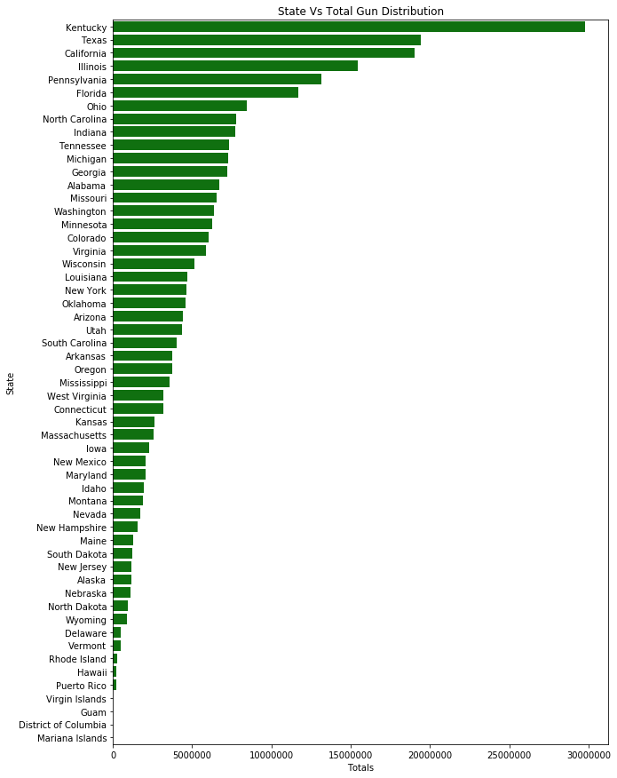

```python
f, ax = plt.subplots(figsize=(10, 15))
t = sns.barplot(x='totals', y=df_gun_trend_by_st.index,data = df_gun_trend_by_st, color = 'g',label='big')
ax.ticklabel_format(style='plain', axis='x',useOffset=False,label='big')
ax.set(ylabel="State",
       xlabel="Totals",label='big')
t.set_title('State Vs Total Gun Distribution')
```

#### Note 22:

The top 5 states with gun activity as indicated in the graphs are

Kentucky

Texas

California

Illinois

Pennsylvania

### Research Question 3 (Which Gun type is preferred?)

```python
df_gun_cat.describe()
```

|  | permit_data | handgun_data | longgun_data | other_data | totals |
| --- | --- | --- | --- | --- | --- |
| count | 12,485.00 | 12,485.00 | 12,485.00 | 12,485.00 | 12,485.00 |
| mean | 6,504.03 | 6,288.61 | 8,315.69 | 160.01 | 21,595.73 |
| std | 23,930.08 | 9,047.67 | 9,675.17 | 915.28 | 32,591.42 |
| min | 0.00 | 0.00 | 0.00 | 0.00 | 0.00 |
| 25% | 0.00 | 989.00 | 2,161.00 | 0.00 | 4,638.00 |
| 50% | 511.00 | 3,273.00 | 5,690.00 | 0.00 | 12,399.00 |
| 75% | 4,319.00 | 7,810.00 | 11,167.00 | 90.00 | 25,453.00 |
| max | 522,188.00 | 113,976.00 | 113,874.00 | 78,008.00 | 541,978.00 |

#### Note 23:

The long gun seems to be the most preferred gun, looking at 75th percentile of the data.

### Research Question 4 (Which state has the highest growth in gun registrations?)

#### Note 24:

The gun registrations can be indicated by the permit checks. A new datframe has been created to group the permit check data for the various states and plot them for the perios of 1998- 2016.

```python
df_gun_cat_permit=df_gun_cat[['state','permit_data']]
```

#### Note 25:

The mean of the values within each state based of the years 1998 - 2016 have been calculated for plotting in the graph below.

```python
df_gun_cat_permit =df_gun_cat_permit.groupby(by=['state']).mean().sort_values(['permit_data'],ascending=False, inplace=False)
```

```
Text(0.5,1,'State Vs Permits 1998 - 2016')
```

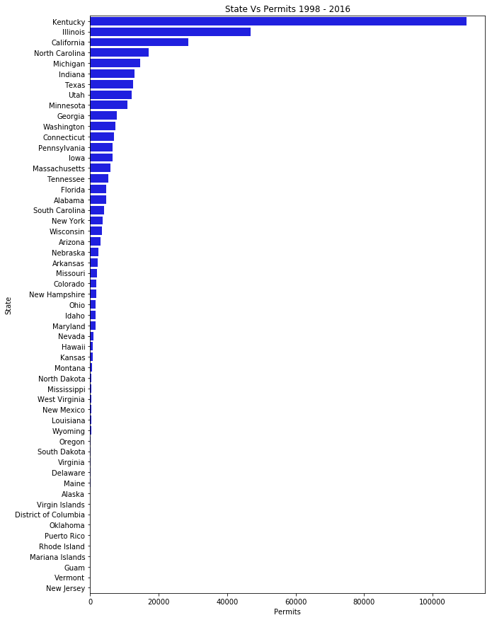

```python
f, ax = plt.subplots(figsize=(10, 15))
t = sns.barplot(x='permit_data', y=df_gun_cat_permit.index,data = df_gun_cat_permit, color = 'b',label='big')
ax.ticklabel_format(style='plain', axis='x',useOffset=False,label='big')
ax.set(ylabel="State",
       xlabel="Permits",label='big')
t.set_title('State Vs Permits 1998 - 2016')
```

#### Note 26:

The top 5 states with a large volume of gun permit checks as indicated in the graphs are

Kentucky

Illinois

California

North Carolina

Michigan

**Note 27:** The factors affecting the totals of permit checks could be multiple such as resale of guns, rental repeats etc. In this case comparing the states with more permits vs gun sales, would not indicate any specific correlation due to limited data.

### Research Question 5 (What census data is most associated with high gun per capita?)

#### Note 28:

To compare the gun data with the census, we will have to drop all information older than 2010 and any additional states in the data sets before bringing the 2 datasets together. That has been done in cell below. The cleaned up gun data is also grouped by the 'state'

```python
df_gun_cat['Year'] = df_gun_cat['Year'].astype(int)
df_gun_cat_clean = df_gun_cat.query('Year>2009')
df_gun_cat_clean = df_gun_cat_clean[['state','totals']]
df_gun_cat_clean = df_gun_cat_clean.groupby(['state'], axis=0).sum().sort_values(['totals'],ascending=False)
```

#### Note 29

The number of states in the 2 datasets do not match. There is a count of 50 in the census data and 55 in the gun data.The additional state data can be dropped.

```python
for s in df_gun_cat_clean.index :
    if s not in df_census_clean.index :
        print (s)
```

```
Puerto Rico
Guam
Virgin Islands
District of Columbia
Mariana Islands
```

```python
df_gun_cat_clean=df_gun_cat_clean.drop(['Puerto Rico','Virgin Islands','Guam','District of Columbia','Mariana Islands'])
```

```python
df_gun_cat_clean.count()
```

```
totals    50
dtype: int64
```

```python
df_census_clean.count()
```

```
New_Fact
Population estimates 2016                                              50
Population estimates base 2010                                         50
Population 2010 %                                                      50
Population 2010                                                        50
Persons under 5 years 2016 %                                           50
Persons under 5 years 2010 %                                           50
Persons under 18 years 2016 %                                          50
Persons under 18 years 2010 %                                          50
Persons 65 years and over 2016 %                                       50
Persons 65 years and over 2010 %                                       50
Female persons 2016 %                                                  50
Female persons 2010 %                                                  50
White alone 2016 %                                                     50
Black or African American alone 2016 %                                 50
American Indian and Alaska Native alone 2016 %                         50
Asian alone 2016 %                                                     50
Native Hawaiian and Other Pacific Islander alone 2016 %                50
Two or More Races 2016 %                                               50
Hispanic or Latino 2016 %                                              50
White alone 2016 %                                                     50
Veterans 2011                                                          50
Foreign born persons 2011 %                                            50
Housing units 2016                                                     50
Housing units 2010                                                     50
Owner-occupied housing unit rate 2011 %                                50
Median value of owner-occupied housing units 2011 $                    50
Median selected monthly owner costs -with a mortgage 2011 $            50
Median selected monthly owner costs -without a mortgage 2011 $         50
Median gross rent 2011 $                                               50
Building permits 2016                                                  50
Households 2011                                                        50
Persons per household 2011                                             50
Living in same house 1 year ago 2011 %                                 50
Language other than English spoken at home 2011 %                      50
High school graduate or higher 2011 %                                  50
Bachelor's degree or higher 2011 %                                     50
With a disability 2011 %                                               50
Persons  without health insurance YN/A %                               50
In civilian labor force 2011 %                                         50
```

[output cut: 11 more lines]

```
Total employer establishments 2015                                     50
Total employment 2015                                                  50
Total annual payroll 2015 $1000                                        50
Total employment 2014 %                                                50
Total nonemployer establishments 2015                                  50
All firms 2012                                                         50
Men-owned firms 2012                                                   50
Women-owned firms 2012                                                 50
Minority-owned firms 2012                                              50
Nonminority-owned firms 2012                                           50
Veteran-owned firms 2012                                               50
Nonveteran-owned firms 2012                                            50
Population per square mile 2010 sq.mi                                  50
Land area in square miles 2010 sq.mi                                   50
dtype: int64
```

#### Note 30:

The Count has now matched in both data sets, we can bring them together to identify the correlation between the 2 datasets

```python
df_result = pd.concat([df_census_clean, df_gun_cat_clean], axis=1, join='inner')
```

#### Note 31:

renaming totals to gun_totals for easy column mapping

```python
df_result.rename(columns={"totals":"gun_totals"}, inplace=True)
```

```python
df_result
```

|  | Population estimates 2016 | Population estimates base 2010 | Population 2010 % | Population 2010 | Persons under 5 years 2016 % | Persons under 5 years 2010 % | Persons under 18 years 2016 % | Persons under 18 years 2010 % | Persons 65 years and over 2016 % | Persons 65 years and over 2010 % | Female persons 2016 % | Female persons 2010 % | White alone 2016 % | Black or African American alone 2016 % | American Indian and Alaska Native alone 2016 % | Asian alone 2016 % | Native Hawaiian and Other Pacific Islander alone 2016 % | Two or More Races 2016 % | Hispanic or Latino 2016 % | White alone 2016 % | Veterans 2011 | Foreign born persons 2011 % | Housing units 2016 | Housing units 2010 | Owner-occupied housing unit rate 2011 % | ... | Total accommodation and food services sales 2012 $1000 | Total health care and social assistance receipts/revenue 2012 $1000 | Total manufacturers shipments 2012 $1000 | … |
| --- | --- | --- | --- | --- | --- | --- | --- | --- | --- | --- | --- | --- | --- | --- | --- | --- | --- | --- | --- | --- | --- | --- | --- | --- | --- | --- | --- | --- | --- | --- |
| Alabama | 4,863,300.00 | 4,780,131.00 | 0.02 | 4,779,736.00 | 0.06 | 0.06 | 0.23 | 0.24 | 0.16 | 0.14 | 0.52 | 0.52 | 0.69 | 0.27 | 0.01 | 0.01 | 0.00 | 0.02 | 0.04 | 0.66 | 363,170.00 | 0.04 | 2,230,185.00 | 2,171,853.00 | 0.69 | ... | 7,576.46 | 26,039.63 | 124,809.76 | … |
| Alaska | 741,894.00 | 710,249.00 | 0.04 | 710,231.00 | 0.07 | 0.08 | 0.25 | 0.26 | 0.10 | 0.08 | 0.48 | 0.48 | 0.66 | 0.04 | 0.15 | 0.06 | 0.01 | 0.07 | 0.07 | 0.61 | 69,323.00 | 0.07 | 310,658.00 | 306,967.00 | 0.63 | ... | 2,221.34 | 6,375.48 | 0.00 | … |
| Arizona | 6,931,071.00 | 6,392,301.00 | 0.08 | 6,392,017.00 | 0.06 | 0.07 | 0.23 | 0.26 | 0.17 | 0.14 | 0.50 | 0.50 | 0.83 | 0.05 | 0.05 | 0.03 | 0.00 | 0.03 | 0.31 | 0.56 | 505,794.00 | 0.14 | 2,961,003.00 | 2,844,526.00 | 0.63 | ... | 13,996.64 | 37,055.88 | 51,243.47 | … |
| Arkansas | 2,988,248.00 | 2,916,025.00 | 0.03 | 2,915,918.00 | 0.06 | 0.07 | 0.24 | 0.24 | 0.16 | 0.14 | 0.51 | 0.51 | 0.79 | 0.16 | 0.01 | 0.02 | 0.00 | 0.02 | 0.07 | 0.73 | 220,953.00 | 0.05 | 1,354,762.00 | 1,316,299.00 | 0.66 | ... | 4,307.26 | 15,792.63 | 62,712.93 | … |
| California | 39,250,017.00 | 37,254,522.00 | 0.05 | 37,253,956.00 | 0.06 | 0.07 | 0.23 | 0.25 | 0.14 | 0.11 | 0.50 | 0.50 | 0.73 | 0.07 | 0.02 | 0.15 | 0.01 | 0.04 | 0.39 | 0.38 | 1,777,410.00 | 0.27 | 14,060,525.00 | 13,680,081.00 | 0.54 | ... | 90,830.37 | 248,953.59 | 512,303.16 | … |
| Colorado | 5,540,545.00 | 5,029,324.00 | 0.10 | 5,029,196.00 | 0.06 | 0.07 | 0.23 | 0.24 | 0.13 | 0.11 | 0.50 | 0.50 | 0.88 | 0.04 | 0.02 | 0.03 | 0.00 | 0.03 | 0.21 | 0.69 | 391,725.00 | 0.10 | 2,339,118.00 | 2,212,898.00 | 0.64 | ... | 13,617.65 | 29,488.16 | 50,447.10 | … |
| Connecticut | 3,576,452.00 | 3,574,114.00 | 0.00 | 3,574,097.00 | 0.05 | 0.06 | 0.21 | 0.23 | 0.16 | 0.14 | 0.51 | 0.51 | 0.81 | 0.12 | 0.01 | 0.05 | 0.00 | 0.02 | 0.16 | 0.68 | 199,331.00 | 0.14 | 1,499,116.00 | 1,487,891.00 | 0.67 | ... | 9,542.07 | 29,573.12 | 55,160.10 | … |
| Delaware | 952,065.00 | 897,936.00 | 0.06 | 897,934.00 | 0.06 | 0.06 | 0.21 | 0.23 | 0.17 | 0.14 | 0.52 | 0.52 | 0.70 | 0.23 | 0.01 | 0.04 | 0.00 | 0.03 | 0.09 | 0.63 | 71,213.00 | 0.09 | 426,149.00 | 405,885.00 | 0.71 | ... | 2,148.44 | 7,003.25 | 22,597.38 | … |
| Florida | 20,612,439.00 | 18,804,592.00 | 0.10 | 18,801,310.00 | 0.06 | 0.06 | 0.20 | 0.21 | 0.20 | 0.17 | 0.51 | 0.51 | 0.78 | 0.17 | 0.01 | 0.03 | 0.00 | 0.02 | 0.25 | 0.55 | 1,507,738.00 | 0.20 | 9,301,642.00 | 8,989,580.00 | 0.65 | ... | 49,817.93 | 124,061.43 | 96,924.11 | … |
| Georgia | 10,310,371.00 | 9,688,680.00 | 0.06 | 9,687,653.00 | 0.06 | 0.07 | 0.24 | 0.26 | 0.13 | 0.11 | 0.51 | 0.51 | 0.61 | 0.32 | 0.01 | 0.04 | 0.00 | 0.02 | 0.09 | 0.53 | 670,617.00 | 0.10 | 4,218,776.00 | 4,088,801.00 | 0.63 | ... | 18,976.61 | 51,800.64 | 155,836.79 | … |
| Hawaii | 1,428,557.00 | 1,360,301.00 | 0.05 | 1,360,301.00 | 0.06 | 0.06 | 0.22 | 0.22 | 0.17 | 0.14 | 0.50 | 0.50 | 0.26 | 0.02 | 0.00 | 0.38 | 0.10 | 0.24 | 0.10 | 0.22 | 110,238.00 | 0.18 | 537,114.00 | 519,508.00 | 0.57 | ... | 9,536.71 | 8,136.95 | 0.00 | … |
| Idaho | 1,683,140.00 | 1,567,650.00 | 0.07 | 1,567,582.00 | 0.07 | 0.08 | 0.26 | 0.27 | 0.15 | 0.12 | 0.50 | 0.50 | 0.93 | 0.01 | 0.02 | 0.01 | 0.00 | 0.02 | 0.12 | 0.82 | 119,711.00 | 0.06 | 700,825.00 | 667,796.00 | 0.69 | ... | 2,680.22 | 7,895.61 | 20,201.43 | … |
| Illinois | 12,801,539.00 | 12,831,574.00 | -0.00 | 12,830,632.00 | 0.06 | 0.07 | 0.23 | 0.24 | 0.15 | 0.12 | 0.51 | 0.51 | 0.77 | 0.15 | 0.01 | 0.06 | 0.00 | 0.02 | 0.17 | 0.62 | 668,933.00 | 0.14 | 5,326,970.00 | 5,296,715.00 | 0.66 | ... | 27,937.38 | 83,431.78 | 281,037.76 | … |
| Indiana | 6,633,053.00 | 6,484,136.00 | 0.02 | 6,483,802.00 | 0.06 | 0.07 | 0.24 | 0.25 | 0.15 | 0.13 | 0.51 | 0.51 | 0.86 | 0.10 | 0.00 | 0.02 | 0.00 | 0.02 | 0.07 | 0.80 | 426,493.00 | 0.05 | 2,854,546.00 | 2,795,541.00 | 0.69 | ... | 13,076.60 | 42,493.12 | 242,763.84 | … |
| Iowa | 3,134,693.00 | 3,046,869.00 | 0.03 | 3,046,355.00 | 0.06 | 0.07 | 0.23 | 0.24 | 0.16 | 0.15 | 0.50 | 0.51 | 0.91 | 0.04 | 0.01 | 0.03 | 0.00 | 0.02 | 0.06 | 0.86 | 211,066.00 | 0.05 | 1,380,162.00 | 1,336,417.00 | 0.71 | ... | 5,468.69 | 18,583.83 | 116,668.83 | … |
| Kansas | 2,907,289.00 | 2,853,129.00 | 0.02 | 2,853,118.00 | 0.07 | 0.07 | 0.25 | 0.26 | 0.15 | 0.13 | 0.50 | 0.50 | 0.87 | 0.06 | 0.01 | 0.03 | 0.00 | 0.03 | 0.12 | 0.76 | 198,396.00 | 0.07 | 1,259,864.00 | 1,233,215.00 | 0.67 | ... | 4,873.41 | 18,248.37 | 86,076.26 | … |
| Kentucky | 4,436,974.00 | 4,339,344.00 | 0.02 | 4,339,367.00 | 0.06 | 0.07 | 0.23 | 0.24 | 0.16 | 0.13 | 0.51 | 0.51 | 0.88 | 0.08 | 0.00 | 0.01 | 0.00 | 0.02 | 0.04 | 0.85 | 297,312.00 | 0.03 | 1,965,556.00 | 1,927,164.00 | 0.67 | ... | 7,500.11 | 26,264.74 | 129,284.44 | … |
| Louisiana | 4,681,666.00 | 4,533,479.00 | 0.03 | 4,533,372.00 | 0.07 | 0.07 | 0.24 | 0.25 | 0.14 | 0.12 | 0.51 | 0.51 | 0.63 | 0.33 | 0.01 | 0.02 | 0.00 | 0.02 | 0.05 | 0.59 | 281,989.00 | 0.04 | 2,036,975.00 | 1,964,981.00 | 0.66 | ... | 11,697.95 | 27,951.79 | 271,191.05 | … |
| Maine | 1,331,479.00 | 1,328,364.00 | 0.00 | 1,328,361.00 | 0.05 | 0.05 | 0.19 | 0.21 | 0.19 | 0.16 | 0.51 | 0.51 | 0.95 | 0.01 | 0.01 | 0.01 | 0.00 | 0.02 | 0.02 | 0.94 | 119,058.00 | 0.04 | 730,705.00 | 721,830.00 | 0.71 | ... | 2,901.35 | 10,297.04 | 16,044.54 | … |
| Maryland | 6,016,447.00 | 5,773,786.00 | 0.04 | 5,773,552.00 | 0.06 | 0.06 | 0.22 | 0.23 | 0.15 | 0.12 | 0.52 | 0.52 | 0.59 | 0.31 | 0.01 | 0.07 | 0.00 | 0.03 | 0.10 | 0.52 | 403,900.00 | 0.14 | 2,447,127.00 | 2,378,814.00 | 0.67 | ... | 12,516.78 | 40,821.90 | 39,532.99 | … |
| Massachusetts | 6,811,779.00 | 6,547,813.00 | 0.04 | 6,547,629.00 | 0.05 | 0.06 | 0.20 | 0.22 | 0.16 | 0.14 | 0.52 | 0.52 | 0.82 | 0.09 | 0.01 | 0.07 | 0.00 | 0.02 | 0.12 | 0.73 | 355,083.00 | 0.15 | 2,858,026.00 | 2,808,254.00 | 0.62 | ... | 17,508.97 | 63,583.09 | 81,927.80 | … |
| Michigan | 9,928,300.00 | 9,884,129.00 | 0.00 | 9,883,640.00 | 0.06 | 0.06 | 0.22 | 0.24 | 0.16 | 0.14 | 0.51 | 0.51 | 0.80 | 0.14 | 0.01 | 0.03 | 0.00 | 0.02 | 0.05 | 0.75 | 626,722.00 | 0.06 | 4,560,055.00 | 4,532,233.00 | 0.71 | ... | 17,962.36 | 63,018.79 | 238,892.38 | … |
| Minnesota | 5,519,952.00 | 5,303,924.00 | 0.04 | 5,303,925.00 | 0.06 | 0.07 | 0.23 | 0.24 | 0.15 | 0.13 | 0.50 | 0.50 | 0.85 | 0.06 | 0.01 | 0.05 | 0.00 | 0.02 | 0.05 | 0.81 | 342,388.00 | 0.08 | 2,409,935.00 | 2,347,201.00 | 0.72 | ... | 11,722.63 | 40,403.57 | 123,076.31 | … |
| Mississippi | 2,988,726.00 | 2,968,103.00 | 0.01 | 2,967,297.00 | 0.06 | 0.07 | 0.24 | 0.26 | 0.15 | 0.13 | 0.52 | 0.51 | 0.59 | 0.38 | 0.01 | 0.01 | 0.00 | 0.01 | 0.03 | 0.57 | 184,774.00 | 0.02 | 1,307,441.00 | 1,274,719.00 | 0.68 | ... | 6,999.18 | 16,630.59 | 66,441.61 | … |
| Missouri | 6,093,000.00 | 5,988,928.00 | 0.02 | 5,988,927.00 | 0.06 | 0.07 | 0.23 | 0.24 | 0.16 | 0.14 | 0.51 | 0.51 | 0.83 | 0.12 | 0.01 | 0.02 | 0.00 | 0.02 | 0.04 | 0.80 | 451,342.00 | 0.04 | 2,760,084.00 | 2,712,729.00 | 0.67 | ... | 12,430.31 | 40,089.32 | 111,535.36 | … |
| Montana | 1,042,520.00 | 989,414.00 | 0.05 | 989,415.00 | 0.06 | 0.06 | 0.22 | 0.23 | 0.18 | 0.15 | 0.50 | 0.50 | 0.89 | 0.01 | 0.07 | 0.01 | 0.00 | 0.03 | 0.04 | 0.86 | 90,000.00 | 0.02 | 497,756.00 | 482,825.00 | 0.67 | ... | 2,420.45 | 6,469.48 | 11,535.24 | … |
| Nebraska | 1,907,116.00 | 1,826,334.00 | 0.04 | 1,826,341.00 | 0.07 | 0.07 | 0.25 | 0.25 | 0.15 | 0.14 | 0.50 | 0.50 | 0.89 | 0.05 | 0.01 | 0.03 | 0.00 | 0.02 | 0.11 | 0.80 | 132,918.00 | 0.07 | 827,156.00 | 796,793.00 | 0.66 | ... | 3,094.50 | 12,869.42 | 57,499.18 | … |
| Nevada | 2,940,058.00 | 2,700,691.00 | 0.09 | 2,700,551.00 | 0.06 | 0.07 | 0.23 | 0.25 | 0.15 | 0.12 | 0.50 | 0.49 | 0.75 | 0.10 | 0.02 | 0.09 | 0.01 | 0.04 | 0.28 | 0.50 | 220,332.00 | 0.19 | 1,221,698.00 | 1,173,814.00 | 0.55 | ... | 27,481.51 | 13,928.51 | 14,719.14 | … |
| New Hampshire | 1,334,795.00 | 1,316,461.00 | 0.01 | 1,316,470.00 | 0.05 | 0.05 | 0.20 | 0.22 | 0.17 | 0.14 | 0.51 | 0.51 | 0.94 | 0.01 | 0.00 | 0.03 | 0.00 | 0.02 | 0.04 | 0.91 | 106,827.00 | 0.06 | 625,307.00 | 614,754.00 | 0.71 | ... | 2,942.28 | 9,616.46 | 18,895.62 | … |
| New Jersey | 8,944,469.00 | 8,791,953.00 | 0.02 | 8,791,894.00 | 0.06 | 0.06 | 0.22 | 0.23 | 0.15 | 0.14 | 0.51 | 0.51 | 0.72 | 0.15 | 0.01 | 0.10 | 0.00 | 0.02 | 0.20 | 0.56 | 393,277.00 | 0.22 | 3,604,409.00 | 3,553,562.00 | 0.65 | ... | 19,673.56 | 60,375.23 | 108,854.97 | … |
| New Mexico | 2,081,015.00 | 2,059,198.00 | 0.01 | 2,059,179.00 | 0.06 | 0.07 | 0.24 | 0.25 | 0.17 | 0.13 | 0.51 | 0.51 | 0.83 | 0.03 | 0.11 | 0.02 | 0.00 | 0.03 | 0.48 | 0.38 | 164,157.00 | 0.10 | 917,568.00 | 901,388.00 | 0.68 | ... | 4,349.67 | 11,236.63 | 29,102.35 | … |
| New York | 19,745,289.00 | 19,378,110.00 | 0.02 | 19,378,102.00 | 0.06 | 0.06 | 0.21 | 0.22 | 0.15 | 0.14 | 0.51 | 0.52 | 0.70 | 0.18 | 0.01 | 0.09 | 0.00 | 0.03 | 0.19 | 0.56 | 828,586.00 | 0.23 | 8,231,687.00 | 8,108,103.00 | 0.54 | ... | 49,285.51 | 155,666.05 | 148,879.93 | … |
| North Carolina | 10,146,788.00 | 9,535,688.00 | 0.06 | 9,535,483.00 | 0.06 | 0.07 | 0.23 | 0.24 | 0.15 | 0.13 | 0.51 | 0.51 | 0.71 | 0.22 | 0.02 | 0.03 | 0.00 | 0.02 | 0.09 | 0.64 | 696,119.00 | 0.08 | 4,540,498.00 | 4,327,528.00 | 0.65 | ... | 18,622.26 | 55,227.50 | 202,344.65 | … |
| North Dakota | 757,952.00 | 672,591.00 | 0.13 | 672,591.00 | 0.07 | 0.07 | 0.23 | 0.22 | 0.14 | 0.14 | 0.49 | 0.49 | 0.88 | 0.03 | 0.06 | 0.01 | 0.00 | 0.02 | 0.04 | 0.85 | 51,179.00 | 0.03 | 368,624.00 | 317,498.00 | 0.64 | ... | 2,045.12 | 5,418.35 | 14,427.36 | … |
| Ohio | 11,614,373.00 | 11,536,727.00 | 0.01 | 11,536,504.00 | 0.06 | 0.06 | 0.23 | 0.24 | 0.16 | 0.14 | 0.51 | 0.51 | 0.82 | 0.13 | 0.00 | 0.02 | 0.00 | 0.02 | 0.04 | 0.80 | 806,531.00 | 0.04 | 5,164,361.00 | 5,127,508.00 | 0.66 | ... | 20,652.78 | 80,915.69 | 313,629.98 | … |
| Oklahoma | 3,923,561.00 | 3,751,615.00 | 0.05 | 3,751,351.00 | 0.07 | 0.07 | 0.24 | 0.25 | 0.15 | 0.14 | 0.51 | 0.51 | 0.75 | 0.08 | 0.09 | 0.02 | 0.00 | 0.06 | 0.10 | 0.66 | 295,847.00 | 0.06 | 1,721,045.00 | 1,664,378.00 | 0.66 | ... | 7,121.15 | 22,795.44 | 74,295.39 | … |
| Oregon | 4,093,465.00 | 3,831,072.00 | 0.07 | 3,831,074.00 | 0.06 | 0.06 | 0.21 | 0.23 | 0.17 | 0.14 | 0.51 | 0.51 | 0.87 | 0.02 | 0.02 | 0.04 | 0.00 | 0.04 | 0.13 | 0.76 | 306,723.00 | 0.10 | 1,732,786.00 | 1,675,562.00 | 0.61 | ... | 8,466.79 | 24,956.82 | 51,349.95 | … |
| Pennsylvania | 12,784,227.00 | 12,702,857.00 | 0.01 | 12,702,379.00 | 0.06 | 0.06 | 0.21 | 0.22 | 0.17 | 0.15 | 0.51 | 0.51 | 0.82 | 0.12 | 0.00 | 0.04 | 0.00 | 0.02 | 0.07 | 0.77 | 870,770.00 | 0.06 | 5,612,002.00 | 5,567,315.00 | 0.69 | ... | 23,504.19 | 96,329.25 | 231,396.18 | … |
| Rhode Island | 1,056,426.00 | 1,052,940.00 | 0.00 | 1,052,567.00 | 0.05 | 0.06 | 0.20 | 0.21 | 0.17 | 0.14 | 0.51 | 0.52 | 0.84 | 0.08 | 0.01 | 0.04 | 0.00 | 0.03 | 0.15 | 0.73 | 66,076.00 | 0.13 | 462,589.00 | 463,388.00 | 0.60 | ... | 2,481.31 | 8,223.00 | 11,262.16 | … |
| South Carolina | 4,961,119.00 | 4,625,410.00 | 0.07 | 4,625,364.00 | 0.06 | 0.07 | 0.22 | 0.23 | 0.17 | 0.14 | 0.52 | 0.51 | 0.69 | 0.28 | 0.01 | 0.02 | 0.00 | 0.02 | 0.06 | 0.64 | 378,959.00 | 0.05 | 2,236,153.00 | 2,137,683.00 | 0.69 | ... | 9,763.82 | 22,941.29 | 99,160.84 | … |
| South Dakota | 865,454.00 | 814,195.00 | 0.06 | 814,180.00 | 0.07 | 0.07 | 0.25 | 0.25 | 0.16 | 0.14 | 0.50 | 0.50 | 0.85 | 0.02 | 0.09 | 0.01 | 0.00 | 0.02 | 0.04 | 0.82 | 63,742.00 | 0.03 | 383,838.00 | 363,438.00 | 0.68 | ... | 1,873.70 | 6,211.73 | 16,882.65 | … |
| Tennessee | 6,651,194.00 | 6,346,298.00 | 0.05 | 6,346,105.00 | 0.06 | 0.06 | 0.23 | 0.24 | 0.16 | 0.13 | 0.51 | 0.51 | 0.79 | 0.17 | 0.00 | 0.02 | 0.00 | 0.02 | 0.05 | 0.74 | 462,414.00 | 0.05 | 2,919,671.00 | 2,812,133.00 | 0.67 | ... | 12,499.01 | 42,383.68 | 139,960.48 | … |
| Texas | 27,862,596.00 | 25,146,100.00 | 0.11 | 25,145,561.00 | 0.07 | 0.08 | 0.26 | 0.27 | 0.12 | 0.10 | 0.50 | 0.50 | 0.79 | 0.13 | 0.01 | 0.05 | 0.00 | 0.02 | 0.39 | 0.43 | 1,539,655.00 | 0.17 | 10,753,629.00 | 9,977,436.00 | 0.62 | ... | 54,480.81 | 145,035.13 | 702,603.07 | … |
| Utah | 3,051,217.00 | 2,763,888.00 | 0.10 | 2,763,885.00 | 0.08 | 0.10 | 0.30 | 0.32 | 0.10 | 0.09 | 0.50 | 0.50 | 0.91 | 0.01 | 0.02 | 0.03 | 0.01 | 0.03 | 0.14 | 0.79 | 134,332.00 | 0.08 | 1,054,164.00 | 979,709.00 | 0.69 | ... | 4,789.28 | 14,521.86 | 50,046.43 | … |
| Vermont | 624,594.00 | 625,741.00 | -0.00 | 625,741.00 | 0.05 | 0.05 | 0.19 | 0.21 | 0.18 | 0.15 | 0.51 | 0.51 | 0.95 | 0.01 | 0.00 | 0.02 | 0.00 | 0.02 | 0.02 | 0.93 | 44,708.00 | 0.04 | 329,525.00 | 322,539.00 | 0.71 | ... | 1,564.27 | 4,458.00 | 9,315.49 | … |
| Virginia | 8,411,808.00 | 8,001,041.00 | 0.05 | 8,001,024.00 | 0.06 | 0.06 | 0.22 | 0.23 | 0.15 | 0.12 | 0.51 | 0.51 | 0.70 | 0.20 | 0.01 | 0.07 | 0.00 | 0.03 | 0.09 | 0.62 | 706,539.00 | 0.12 | 3,491,054.00 | 3,364,939.00 | 0.66 | ... | 17,795.90 | 47,705.00 | 96,389.87 | … |
| Washington | 7,288,000.00 | 6,724,545.00 | 0.08 | 6,724,540.00 | 0.06 | 0.07 | 0.22 | 0.23 | 0.15 | 0.12 | 0.50 | 0.50 | 0.80 | 0.04 | 0.02 | 0.09 | 0.01 | 0.05 | 0.12 | 0.69 | 564,864.00 | 0.13 | 3,025,685.00 | 2,885,677.00 | 0.62 | ... | 14,297.28 | 43,966.89 | 131,530.60 | … |
| West Virginia | 1,831,102.00 | 1,853,011.00 | -0.01 | 1,852,994.00 | 0.06 | 0.06 | 0.20 | 0.21 | 0.19 | 0.16 | 0.51 | 0.51 | 0.94 | 0.04 | 0.00 | 0.01 | 0.00 | 0.02 | 0.01 | 0.92 | 150,021.00 | 0.01 | 886,640.00 | 881,917.00 | 0.72 | ... | 4,036.33 | 12,259.40 | 24,553.07 | … |
| Wisconsin | 5,778,708.00 | 5,687,289.00 | 0.02 | 5,686,986.00 | 0.06 | 0.06 | 0.22 | 0.24 | 0.16 | 0.14 | 0.50 | 0.50 | 0.88 | 0.07 | 0.01 | 0.03 | 0.00 | 0.02 | 0.07 | 0.82 | 381,940.00 | 0.05 | 2,668,444.00 | 2,624,358.00 | 0.67 | ... | 10,303.26 | 40,680.62 | 177,728.93 | … |
| Wyoming | 585,501.00 | 563,767.00 | 0.04 | 563,626.00 | 0.07 | 0.07 | 0.24 | 0.24 | 0.15 | 0.12 | 0.49 | 0.49 | 0.93 | 0.01 | 0.03 | 0.01 | 0.00 | 0.02 | 0.10 | 0.84 | 48,505.00 | 0.04 | 270,600.00 | 261,868.00 | 0.69 | ... | 1,644.84 | 3,291.48 | 10,783.79 | … |

50 rows × 65 columns

#### Note 32:

In order to identify the top positive correlation coefficients, in the dataset, pearson's method is used.

**Limitations of this method:**

The main drawback of the Pearson correlation coefficient is that it can only detect linear correlations.In the real world, correlations are not necessarily of linear nature. Reference: http://pythonhosted.org/ibmdbpy/feature_selection.html

```python
pearson_corr = result[result.columns[1:]].corr(method="pearson")['gun_totals'][:-1]
```

```python
df_pearson_corr=pd.DataFrame(pearson_corr)
df_pearson_corr['Year'] = df_pearson_corr.index
df_pearson_corr['Year'] = df_pearson_corr['Year'].str.extract('(20\d+)', expand=True)
```

#### Note 33:

The Factors are indicated below and have been sorted to show the positive values on top along with the year that we will be considering. This would also be a limitation to accuracy.

```python
df_pearson_corr.sort_values(['gun_totals','Year'],axis=0,ascending=False, inplace=False)
```

|  | gun_totals | Year |
| --- | --- | --- |
| Total manufacturers shipments 2012 $1000 | 0.61 | 2012 |
| Veterans 2011 | 0.59 | 2011 |
| Housing units 2016 | 0.58 | 2016 |
| Households 2011 | 0.58 | 2011 |
| Housing units 2010 | 0.58 | 2010 |
| Population estimates base 2010 | 0.57 | 2010 |
| Population 2010 | 0.57 | 2010 |
| Nonminority-owned firms 2012 | 0.57 | 2012 |
| Veteran-owned firms 2012 | 0.57 | 2012 |
| Total retail sales 2012 $1000 | 0.57 | 2012 |
| Total employment 2015 | 0.56 | 2015 |
| Total merchant wholesaler sales 2012 $1000 | 0.54 | 2012 |
| Total nonemployer establishments 2015 | 0.54 | 2015 |
| Total employer establishments 2015 | 0.54 | 2015 |
| All firms 2012 | 0.54 | 2012 |
| Men-owned firms 2012 | 0.54 | 2012 |
| Nonveteran-owned firms 2012 | 0.53 | 2012 |
| Total health care and social assistance receipts/revenue 2012 $1000 | 0.53 | 2012 |
| Women-owned firms 2012 | 0.53 | 2012 |
| Total annual payroll 2015 $1000 | 0.52 | 2015 |
| Building permits 2016 | 0.51 | 2016 |
| Total accommodation and food services sales 2012 $1000 | 0.51 | 2012 |
| Minority-owned firms 2012 | 0.48 | 2012 |
| Persons in poverty YN/A % | 0.32 | NaN |
| Total employment 2014 % | 0.31 | 2014 |
| Mean travel time to work (minutes) 2011 | 0.21 | 2011 |
| Hispanic or Latino 2016 % | 0.18 | 2016 |
| With a disability 2011 % | 0.16 | 2011 |
| Language other than English spoken at home 2011 % | 0.16 | 2011 |
| Female persons 2016 % | 0.15 | 2016 |
| Persons per household 2011 | 0.15 | 2011 |
| Foreign born persons 2011 % | 0.14 | 2011 |
| Female persons 2010 % | 0.14 | 2010 |
| Persons under 18 years 2010 % | 0.12 | 2010 |
| Black or African American alone 2016 % | 0.11 | 2016 |
| Persons under 18 years 2016 % | 0.10 | 2016 |
| Land area in square miles 2010 sq.mi | 0.06 | 2010 |
| Persons under 5 years 2010 % | 0.06 | 2010 |
| Persons without health insurance YN/A % | 0.06 | NaN |
| Persons under 5 years 2016 % | 0.06 | 2016 |
| White alone 2016 % | 0.04 | 2016 |
| White alone 2016 % | 0.04 | 2016 |
| Population 2010 % | 0.03 | 2010 |
| Living in same house 1 year ago 2011 % | 0.03 | 2011 |
| Asian alone 2016 % | -0.03 | 2016 |
| Population per square mile 2010 sq.mi | -0.07 | 2010 |
| Median gross rent 2011 $ | -0.08 | 2011 |
| Owner-occupied housing unit rate 2011 % | -0.10 | 2011 |
| White alone 2016 % | -0.10 | 2016 |
| White alone 2016 % | -0.10 | 2016 |
| Median selected monthly owner costs -with a mortgage 2011 $ | -0.10 | 2011 |
| Persons 65 years and over 2010 % | -0.12 | 2010 |
| Native Hawaiian and Other Pacific Islander alone 2016 % | -0.13 | 2016 |
| Two or More Races 2016 % | -0.15 | 2016 |
| Persons 65 years and over 2016 % | -0.15 | 2016 |
| Median value of owner-occupied housing units 2011 $ | -0.15 | 2011 |
| Median selected monthly owner costs -without a mortgage 2011 $ | -0.17 | 2011 |
| Bachelor's degree or higher 2011 % | -0.17 | 2011 |
| Per capita income in past 12 months (in 2015 dollars) 2015 $ | -0.19 | 2015 |
| Median household income (in 2015 dollars) 2015 $ | -0.21 | 2015 |
| American Indian and Alaska Native alone 2016 % | -0.22 | 2016 |
| In civilian labor force 2011 % | -0.25 | 2011 |
| In civilian labor force 2011 % | -0.25 | 2011 |
| Total retail sales per capita 2012 $ | -0.27 | 2012 |
| In civilian labor force 2011 % | -0.30 | 2011 |
| In civilian labor force 2011 % | -0.30 | 2011 |
| High school graduate or higher 2011 % | -0.44 | 2011 |

#### Note 34:

Based on Pearson's Correlation, I chose the folowing top 5 factors related to higher gun totals:

* Total manufacturers shipments

* Veterans population

* Housing units owned by the population

* Population estimates

* Total Employment

In order to analyze better, I will be combining the 5 top states with the 5 chosen census data to provide an insight on the relationship between these census information and the top 5 states with high gun registrations.

### Research Question 6 ( What can be found about the top 5 census data on the states with maximum gun registrations?)

```python
df_result.columns
```

```
Index(['Population estimates 2016 ', 'Population estimates base 2010 ',
       'Population 2010 %', 'Population 2010 ', 'Persons under 5 years 2016 %',
       'Persons under 5 years 2010 %', 'Persons under 18 years 2016 %',
       'Persons under 18 years 2010 %', 'Persons 65 years and over 2016 %',
       'Persons 65 years and over 2010 %', 'Female persons 2016 %',
       'Female persons 2010 %', 'White alone 2016 %',
       'Black or African American alone 2016 %',
       'American Indian and Alaska Native alone 2016 %', 'Asian alone 2016 %',
       'Native Hawaiian and Other Pacific Islander alone 2016 %',
       'Two or More Races 2016 %', 'Hispanic or Latino 2016 %',
       'White alone 2016 %', 'Veterans 2011 ', 'Foreign born persons 2011 %',
       'Housing units 2016 ', 'Housing units 2010 ',
       'Owner-occupied housing unit rate 2011 %',
       'Median value of owner-occupied housing units 2011 $',
       'Median selected monthly owner costs -with a mortgage 2011 $',
       'Median selected monthly owner costs -without a mortgage 2011 $',
       'Median gross rent 2011 $', 'Building permits 2016 ',
       'Households 2011 ', 'Persons per household 2011 ',
       'Living in same house 1 year ago 2011 %',
       'Language other than English spoken at home 2011 %',
       'High school graduate or higher 2011 %',
       'Bachelor's degree or higher 2011 %', 'With a disability 2011 %',
       'Persons  without health insurance YN/A %',
       'In civilian labor force 2011 %', 'In civilian labor force 2011 %',
       'Total accommodation and food services sales 2012 $1000',
       'Total health care and social assistance receipts/revenue 2012 $1000',
       'Total manufacturers shipments 2012 $1000',
       'Total merchant wholesaler sales 2012 $1000',
       'Total retail sales 2012 $1000', 'Total retail sales per capita 2012 $',
       'Mean travel time to work (minutes) 2011 ',
       'Median household income (in 2015 dollars) 2015 $',
       'Per capita income in past 12 months (in 2015 dollars) 2015 $',
       'Persons in poverty YN/A %', 'Total employer establishments 2015 ',
       'Total employment 2015 ', 'Total annual payroll 2015 $1000',
       'Total employment 2014 %', 'Total nonemployer establishments 2015 ',
       'All firms 2012 ', 'Men-owned firms 2012 ', 'Women-owned firms 2012 ',
       'Minority-owned firms 2012 ', 'Nonminority-owned firms 2012 ',
       'Veteran-owned firms 2012 ', 'Nonveteran-owned firms 2012 ',
       'Population per square mile 2010 sq.mi',
       'Land area in square miles 2010 sq.mi', 'gun_totals'],
      dtype='object')
```

#### Note 35:

A new dataframe using the 5 chosen census data and top states will be created to analyze the per capita data for these census data.

```python
df_result_temp = df_result[['Total manufacturers shipments 2012 $1000','Veterans 2011 ','Housing units 2016 ','Population estimates base 2010 ','Total employment 2015 ','gun_totals']]
```

```python
df_result_temp = df_result_temp.loc[['Kentucky','Illinois','California','North Carolina','Michigan']]
```

```python
df_result_temp['Gun_tot_mfr_shpmnt_per_capita'] = list(map(lambda x,y: x/y, df_result_temp['gun_totals'],df_result_temp['Total manufacturers shipments 2012 $1000']))
df_result_temp['Gun_tot_Vet_pop_per_capita'] = list(map(lambda x,y: x/y, df_result_temp['gun_totals'],df_result_temp['Veterans 2011 ']))
df_result_temp['Gun_tot_housing_unt_per_capita'] = list(map(lambda x,y: x/y, df_result_temp['gun_totals'],df_result_temp['Housing units 2016 ']))
df_result_temp['Gun_tot_pop_est_per_capita'] = list(map(lambda x,y: x/y, df_result_temp['gun_totals'],df_result_temp['Population estimates base 2010 ']))
df_result_temp['Gun_tot_emp_per_capita'] = list(map(lambda x,y: x/y, df_result_temp['gun_totals'],df_result_temp['Total employment 2015 ']))
```

Calculating the gun total per capita for each of the census data

```python
df_result_per_capita=df_result_temp[['Gun_tot_mfr_shpmnt_per_capita','Gun_tot_Vet_pop_per_capita','Gun_tot_housing_unt_per_capita','Gun_tot_pop_est_per_capita','Gun_tot_emp_per_capita']]
```

```python
df_result_per_capita
```

|  | Gun_tot_mfr_shpmnt_per_capita | Gun_tot_Vet_pop_per_capita | Gun_tot_housing_unt_per_capita | Gun_tot_pop_est_per_capita | Gun_tot_emp_per_capita |
| --- | --- | --- | --- | --- | --- |
| Kentucky | 167.38 | 72.78 | 11.01 | 4.99 | 13.70 |
| Illinois | 33.88 | 14.23 | 1.79 | 0.74 | 1.75 |
| California | 21.48 | 6.19 | 0.78 | 0.30 | 0.77 |
| North Carolina | 22.10 | 6.42 | 0.98 | 0.47 | 1.22 |
| Michigan | 14.70 | 5.61 | 0.77 | 0.36 | 0.94 |

#### Note 36:

```
Text(0,0.5,'Per capita')
```

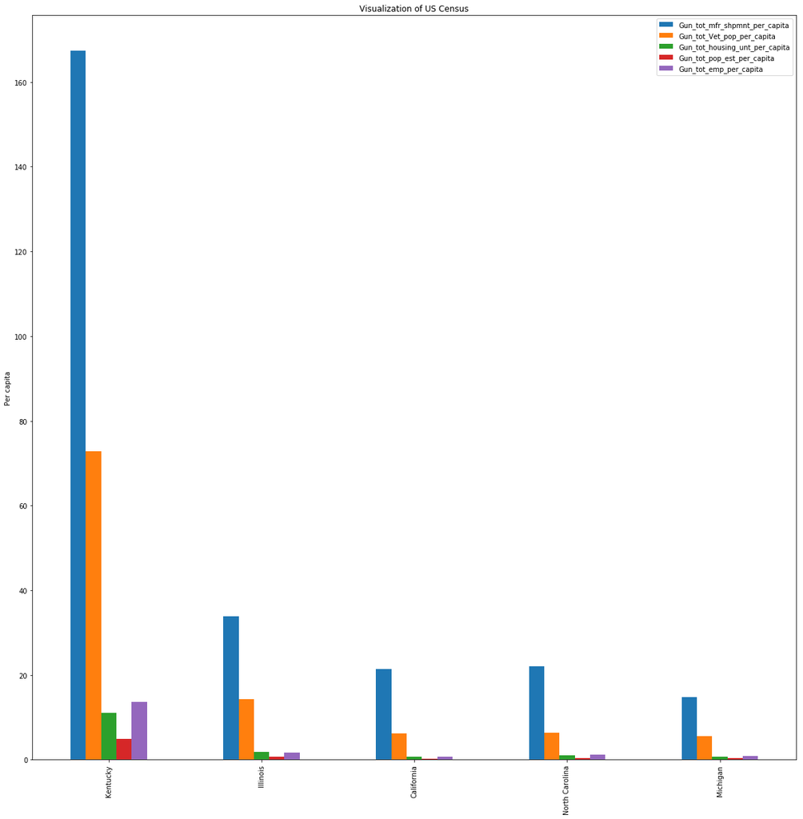

```python
ax = df_result_per_capita.plot(kind='bar', x = df_result_per_capita.index, figsize=(20,20), title = 'Visualization of US Census')
ax.set_ylabel('Per capita')
```

#### Note 37:

The second prominent factor is that the states with more vetrans have more gun checks.

The impact of population seems to be of least concern.

## Conclusions

**Has the overall purchase of guns increased over the years?**

*It can be inferred as Yes, due to the growing trend :* Answer1

**Which state has the highest growth in gun registrations?**

*KY, TX, CA , IL, PA :* Answer2

**Which Gun type is preferred?**

*long Gun* Answer3

**What census data is most associated with high gun per capita?**

*After applying the pearsons method it can be inferred from the data that Total manufacturers shipments / Veterans population / Housing units owned by the population /Population estimates are factors that have a high correlation value compared to the rest of the data.* Answer5

#### Limitations:

As indicated in previous notes, there are limitations with this data which may impact the findings

1) Null values in the datasets, would generate some gaps,they were assumed to be 0.

2) As indicated in the fact note of the census data, in some cases the data was suppresed or not available.

3) The time periods for the census data are not uniform and hence may cause discrepancies.